# PSC mice P76_3

Rnaseq dataset part2

# 1 Introduction

This report presents a preliminary transcriptomic analysis of liver samples from a PSC mouse model (experiment P76_3), asking how diet and sex jointly shape hepatic gene expression.

RNA-seq data was processed using custom bioinformatic pipeline available at https://github.com/xpolak37/RNAseq_workflow.

Data from 44 animals (SD: 10F/11M; GFD: 11F/12M) were modeled in DESeq2 using the design Date + Diet + Sex + Diet:Sex, with SD and female as reference levels; the Diet×Sex interaction is the primary term of interest, since it tests whether diet acts differently in the two sexes rather than assuming a single “overall” diet effect.

After keeping genes detected (non-zero count) in at least 5 samples of at least one Diet × Sex group, 25981 genes were retained (section 3.1).

This part covers global structure (PCA, sample-distance heatmap, PERMANOVA), targeted differential expression and curated gene panels (masculinization, lipogenesis, liver-damage, bile-acid). Integration with serum bile-acid phenotypes and clinical parameters, and pathway enrichment (Hallmark, KEGG, Reactome), are in part 3.

One caveat runs through the whole analysis: the four groups were collected in blocks (SD_F first, GFD_M last; see A3), so collection order, which carries time-of-day and feeding-state information, is strongly confounded with group.

**Open code**

```r
source("custom_functions_rnaseq.R")
```

# 2 Import

Two inputs are loaded:

- **Gene-level expression** (`tpm_data.tsv`): TPM values per gene and sample, produced by the RNA-seq pipeline.
- **Sample metadata** (`metadata_P076v3.xlsx`): one row per animal with diet, sex, collection date/order and other annotations. Rows without an RNA-seq sample ID (`SampleIAB`) are dropped, a combined `Group` label (e.g. `GFD_M`) is created from Diet and Sex, and `SampleID` is set to the RNA-seq sample ID so that metadata rows can be matched to expression data.

**Open code**

```r
# load gene level data
gene_df <- fread("../../Data/tpm_data.tsv") %>% as.data.frame()

# load metadata
sample_metadata <- read.xlsx("../../Data/metadata_P076v3.xlsx",detectDates = TRUE) %>%
  dplyr::filter(!is.na(SampleIAB)) %>%
  dplyr::mutate(Group=paste(Diet,Sex,sep = "_")) %>%
  dplyr::mutate(SampleID=SampleIAB)
```

**Open code**

```r
# assign colors to groups
cond_colours <- c("#e59866","#7fb3d5","#b03a2e","#1c4c78")[as.factor(sample_metadata$Group)]
names(cond_colours) <- sample_metadata$Group

group_colours <- c("GFD_F"="#e59866",
                   "GFD_M"= "#7fb3d5",
                   "SD_F"="#b03a2e",
                  "SD_M"="#1c4c78")
```

# 3 Analysis

The chunk below builds the input for differential expression.

- `tx2gene` is a transcript-to-gene lookup (`tx2gene.tsv`) built from the same Ensembl GRCm39 annotation that was used for the Salmon index, including gene symbols. Using the same release as the index ensures that every quantified transcript can be mapped to a gene.
- `tximport()` reads the Salmon quantification of every sample and sums transcript-level estimates into gene-level estimated counts. It also keeps average transcript lengths, which DESeq2 later uses as a per-sample correction for differences in transcript usage. Transcript version suffixes (e.g. `.3`) are ignored so that IDs match the annotation.

**Open code**

```r
# transcript-to-gene table from the GRCm39 annotation used for the Salmon index
tx2gene <- fread("../../Data/tx2gene.tsv")

# Import Salmon quantifications
files <- read.table("../../Data/samples.txt")$V2
files <- paste0("../../", files)
names(files) <- sample_metadata$SampleID

# txi$counts is a gene x sample matrix of estimated counts.
txi <- tximport(
  files,
  type = "salmon",
  tx2gene = tx2gene[, c("tx_id", "gene_id")],
  ignoreTxVersion = TRUE             # handles the ".3" version suffixes
)
```

**Saving dataset**

**Open code**

```r
save(tx2gene,txi,file="../Results/transcript_import.RData")
```

**Load dataset**

**Open code**

```r
load("../Results/transcript_import.RData")

# metadata to factors
sample_metadata <- sample_metadata %>%
  mutate(
    Diet  = factor(Diet, levels = c("SD", "GFD")),
    Sex   = factor(Sex,  levels = c("F", "M")),
    Group = factor(paste(Diet, Sex, sep = "_")),
    Date = factor(gsub("-","_",Date))
  )

# Build DESeq2 object (factorial design)
dds <- DESeqDataSetFromTximport(
  txi,
  colData = sample_metadata,
  design  = ~ Date + Diet * Sex            # = Diet + Sex + Diet:Sex
)
```

```
using counts and average transcript lengths from tximport
```

## 3.1 Filter

Genes that are barely detected carry almost no information and only add to the multiple-testing burden. The filter below keeps a gene if it has a non-zero count in at least **5 samples** of at least one group (SD_F, SD_M, GFD_F or GFD_M). Requiring detection within a single group, rather than across all samples, keeps genes that are switched on in only one condition.

**Open code**

```r
# genes detected (count > 0) in >= 5 samples of at least one group
min_count <- 5
grp <- sample_metadata$Group
keep <- sapply(levels(factor(grp)), function(g) {
  rowSums(counts(dds)[, grp == g, drop = FALSE] > 0) >= min_count
})
keep <- rowSums(keep) >= 1   # passes in at least one group
dds  <- dds[keep, ]

cat(sum(keep), "genes kept after filtering\n")
```

```
25981 genes kept after filtering
```

## 3.2 Run Deseq

Design: Date + Diet + Sex + Diet:Sex.

Reference factors: Diet: SD Sex: F

The full model is:

**Date** - a covariate we’re adjusting for (collection date) **Diet** - main effect of diet (Effect of diet on reference SEX=F) **Sex** - main effect of sex (Effect of sex on reference Diet=SD) **Diet:Sex** - the interaction: whether diet’s effect on expression differs between sexes (or equivalently, whether the sex difference depends on diet). This is usually the term we care about.

**Open code**

```r
dds <- DESeq(dds)
```

```
using 'avgTxLength' from assays(dds), correcting for library size
```

```
-- replacing outliers and refitting for 13 genes
-- DESeq argument 'minReplicatesForReplace' = 7
-- original counts are preserved in counts(dds)
```

**Open code**

```r
resultsNames(dds)   # shows the coefficients
```

```
[1] "Intercept"           "Date_27_11_vs_26_11" "Diet_GFD_vs_SD"
[4] "Sex_M_vs_F"          "DietGFD.SexM"
```

**NoteExplanation**

**Intercept**: the model’s baseline: the expected (log2) expression for a sample in every reference category at once — SD diet, female, date 26_11. Every other coefficient is a shift relative to this baseline.

**Date_27_11_vs_26_11**: the effect of processing date, 27_11 relative to 26_11.

**Diet_GFD_vs_SD**: the diet effect (GFD vs SD), in **females** only. Because Sex’s reference is F, this coefficient is the GFD-vs-SD contrast evaluated at Sex = F. It is not “the diet effect overall.”

**Sex_M_vs_F**: the sex effect (M vs F), in SD animals only. Symmetrically, Diet’s reference is SD, so this is the M-vs-F contrast evaluated at Diet = SD. Not “sex effect overall”.

**DietGFD.SexM**: the interaction: how much the diet effect differs between the sexes (equivalently, how much the sex effect differs between diets — it’s symmetric). Concretely, it’s (diet effect in males) − (diet effect in females). Also, its (sex effect in GFD) − (sex effect in SD). If it’s zero, diet acts the same in both sexes. If it’s non-zero and significant, **diet’s effect is sex-dependent**. It is the only coefficient that tests whether the sex difference changes with diet (Sex_M_vs_F tests the sex difference itself, but only within SD).

## 3.3 PCA

Firstly, variance-stabilizing transformation (VST) is applied to our DESeq2 data. This is a preprocessing step used mainly for visualization and clustering, not for the differential-expression testing itself.

**Why?** Raw RNA-seq counts have a strong mean–variance dependence — highly expressed genes show much larger absolute variance than low-expressed ones. This “heteroskedasticity” means that if we feed raw or simply log-transformed counts into things like PCA or a sample-distance heatmap, the results get dominated by a handful of high-count genes, and the log of near-zero counts blows up the noise at the low end.

**What it does?** vst() transforms the counts so that variance becomes roughly constant across the range of mean expression, putting genes on a more comparable footing.

**Open code**

```r
# VST
vsd <- vst(dds, blind = TRUE)

# PCA coloured by Diet, shaped by Sex — tells us which factor dominates variance.
pca_data <- plotPCA(vsd, intgroup = c("Diet", "Sex","Date"), returnData = TRUE)
```

```
using ntop=500 top features by variance
```

**Open code**

```r
pv <- round(100 * attr(pca_data, "percentVar"))
```

**All in one**

**Open code**

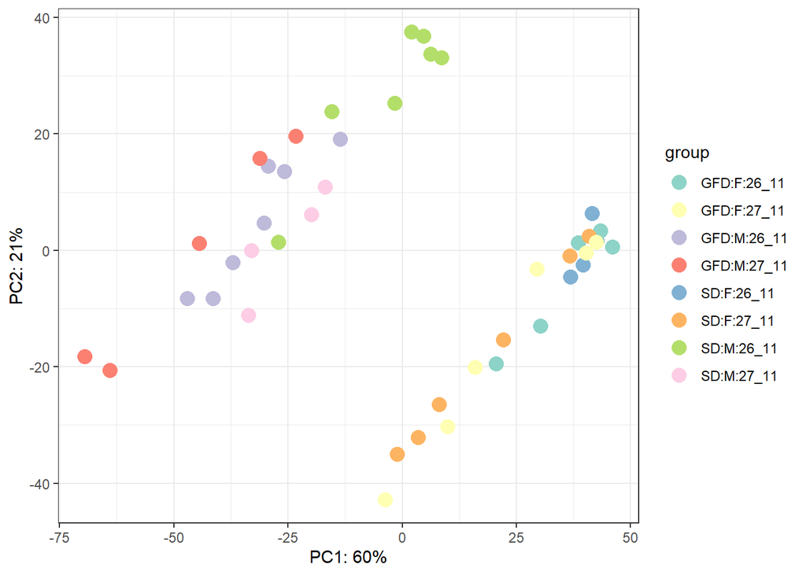

```r
ggplot(pca_data, aes(PC1, PC2, colour = group)) +
  geom_point(size = 4) +
  labs(x = paste0("PC1: ", pv[1], "%"), y = paste0("PC2: ", pv[2], "%")) +
  theme_bw() +
  scale_color_discrete(palette="Set3")
```

**Diet + Sex**

Sex has the most visible effect (it separates the samples along PC1).

**Open code**

```r
pca_data2 <- plotPCA(vsd, intgroup = c("Diet", "Sex","Date"),
                     returnData = TRUE, pcsToUse = c(1,3))
```

```
using ntop=500 top features by variance
```

**Open code**

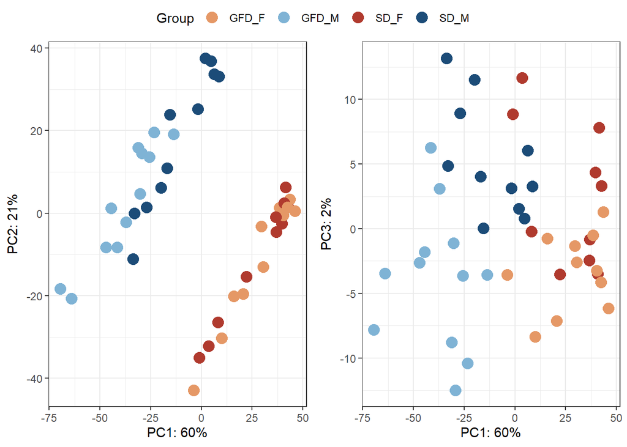

```r
pv2 <- round(100 * attr(pca_data2, "percentVar"))   # % variance of PC1 and PC3

pca_data <- pca_data %>% dplyr::mutate(Group=paste(Diet,Sex,sep = "_"))
pca_data2 <- pca_data2 %>% dplyr::mutate(Group=paste(Diet,Sex,sep = "_"))

p1 <- ggplot(pca_data, aes(PC1, PC2, colour = Group)) +
  geom_point(size = 4) +
  scale_color_manual(values=group_colours) +
  labs(x = paste0("PC1: ", pv[1], "%"), y = paste0("PC2: ", pv[2], "%")) +
  theme_bw()

p2 <- ggplot(pca_data2, aes(PC1, PC3, colour = Group)) +
  geom_point(size = 4) +
  scale_color_manual(values=group_colours) +
  labs(x = paste0("PC1: ", pv2[1], "%"), y = paste0("PC3: ", pv2[2], "%")) +
  theme_bw()

ggarrange(p1,p2,common.legend = TRUE)
```

**Open code**

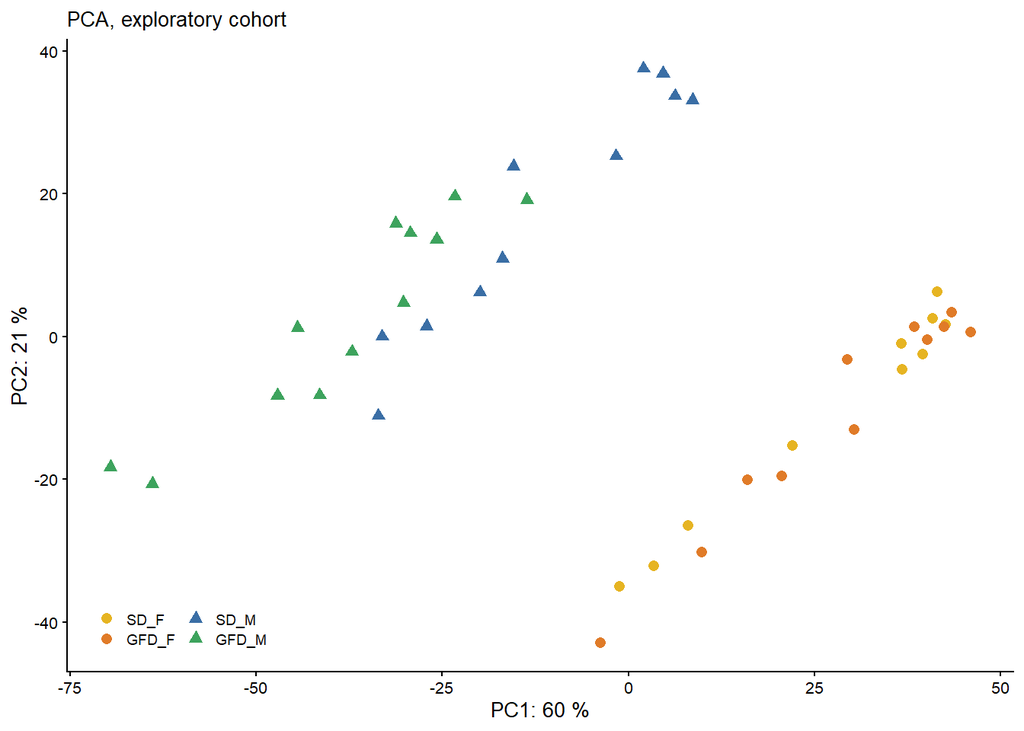

```r
# Adjust names to match your Group levels exactly
pca_data$Group <- factor(
  pca_data$Group,levels = c("SD_F", "GFD_F", "SD_M", "GFD_M"))

group_colours <- c("SD_F" = "#E6B422", "GFD_F" = "#E07B28",
                   "SD_M" = "#3A6EA5", "GFD_M" = "#3DA35D")
group_shapes  <- c("SD_F" = 16, "GFD_F" = 16,
                   "SD_M" = 17, "GFD_M" = 17)
group_labels  <- c("SD_F" = "F SD", "GFD_F" = "F GFD",
                   "SD_M" = "M SD", "GFD_M" = "M GFD")

f_5a <- ggplot(pca_data, aes(PC1, PC2, colour = Group, shape = Group)) +
  geom_point(size = 2.2) +
  scale_colour_manual(values = group_colours) +
  scale_shape_manual(values = group_shapes) +
  labs(x = paste0("PC1: ", pv[1], " %"),
       y = paste0("PC2: ", pv[2], " %"),
       title = "PCA, exploratory cohort") +
  guides(colour = guide_legend(ncol = 2), shape = guide_legend(ncol = 2)) +
  theme_classic(base_size = 10) +
  theme(
    plot.title        = element_text(size = 10, face = "plain"),
    plot.tag          = element_text(size = 14, face = "bold"),
    axis.text         = element_text(colour = "black", size = 8),
    axis.line         = element_line(linewidth = 0.4),
    axis.ticks        = element_line(linewidth = 0.4),
    legend.position   = c(0.02, 0.02),
    legend.justification = c(0, 0),
    legend.title      = element_blank(),
    legend.text       = element_text(size = 7),
    legend.key.size   = unit(0.35, "cm"),
    legend.background = element_blank()
  )

f_5a
```

**Open code**

```r
save(f_5a,file = "../Results/figures/F5A.RData")
```

## 3.4 PCA + boxplots

The PC1 and PC2 coordinates from the PCA above are compared between groups of samples. Each plot shows the distribution of sample scores on a component, and a Wilcoxon rank-sum test checks whether the groups differ on that component (stars: * p < 0.05, ** p < 0.01, *** p < 0.001, ns = not significant). This shows which factor each component captures. These tests are exploratory: p-values are not corrected for the number of comparisons.

**Sex**

**Open code**

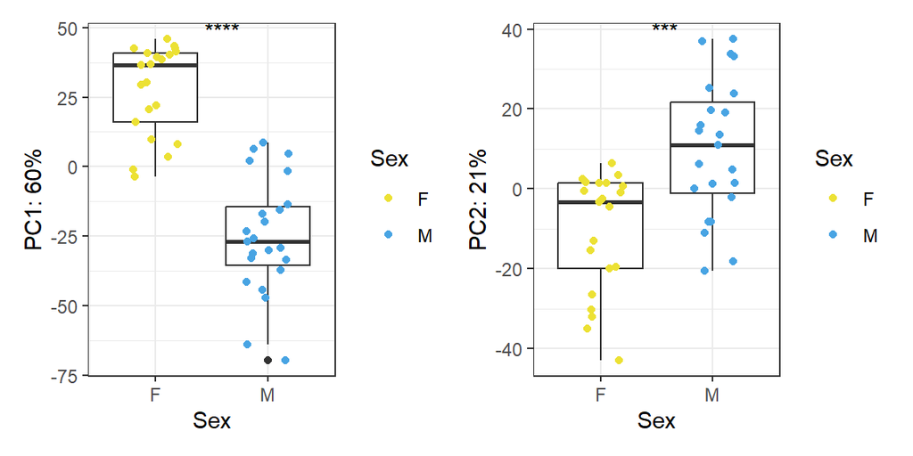

```r
p1 <- ggplot(pca_data, aes(x=Sex, y=PC1)) +
  geom_boxplot() +
  geom_jitter(width = 0.2,height = 0,aes(colour = Sex)) +
  labs(y = paste0("PC1: ", pv[1], "%"), x = "Sex") +
  theme_bw() +
  scale_color_manual(values=c("#ece134","#48a4e3")) +
  stat_compare_means(method = "wilcox.test",
                   label = "p.signif",        # ***, **, *, ns
                   label.x = 1.5)             # horizontal position

p2 <- ggplot(pca_data, aes(x=Sex, y=PC2)) +
  geom_boxplot() +
  geom_jitter(width = 0.2,height = 0,aes(colour = Sex)) +
  labs(y = paste0("PC2: ", pv[2], "%"), x = "Sex") +
  theme_bw() +
  scale_color_manual(values=c("#ece134","#48a4e3")) +
  stat_compare_means(method = "wilcox.test",
                   label = "p.signif",        # ***, **, *, ns
                   label.x = 1.5)             # horizontal position

wrap_plots(p1,p2)
```

**Date**

**Open code**

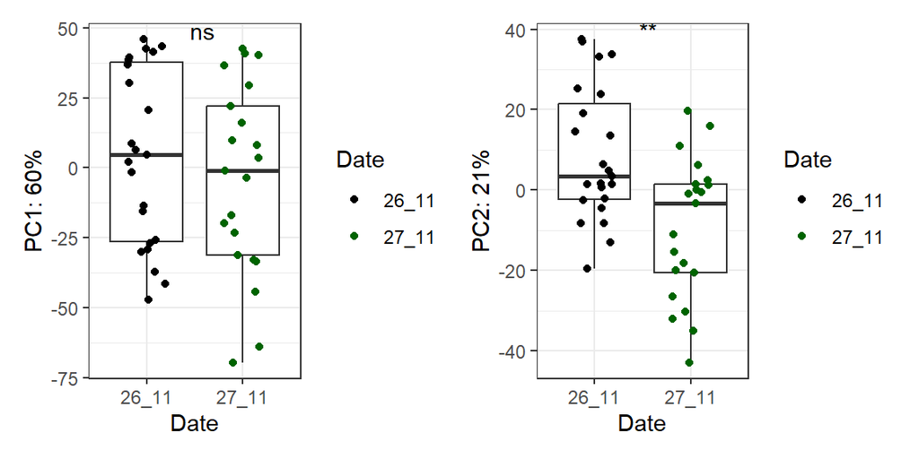

```r
p1 <- ggplot(pca_data, aes(x=Date, y=PC1)) +
  geom_boxplot() +
  geom_jitter(width = 0.2,height = 0,aes(colour = Date)) +
  labs(y = paste0("PC1: ", pv[1], "%"), x = "Date") +
  theme_bw() +
  scale_color_manual(values=c("black","darkgreen")) +
  stat_compare_means(method = "wilcox.test",
                   label = "p.signif",        # ***, **, *, ns
                   label.x = 1.5)             # horizontal position

p2 <- ggplot(pca_data, aes(x=Date, y=PC2)) +
  geom_boxplot() +
  geom_jitter(width = 0.2,height = 0,aes(colour = Date)) +
  labs(y = paste0("PC2: ", pv[2], "%"), x = "Date") +
  theme_bw() +
  scale_color_manual(values=c("black","darkgreen")) +
  stat_compare_means(method = "wilcox.test",
                   label = "p.signif",        # ***, **, *, ns
                   label.x = 1.5)             # horizontal position

wrap_plots(p1,p2)
```

**Diet**

**Open code**

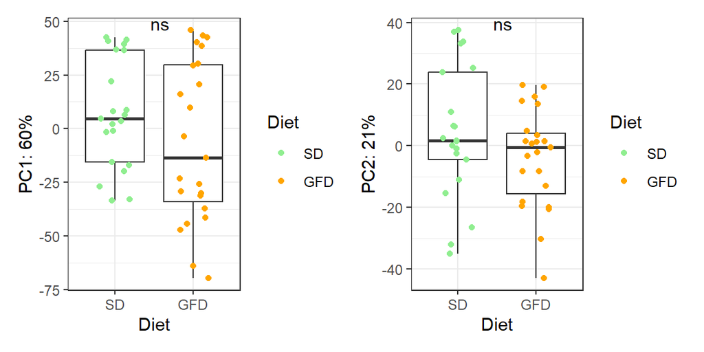

```r
p1 <- ggplot(pca_data, aes(x=Diet, y=PC1)) +
  geom_boxplot() +
  geom_jitter(width = 0.2,height = 0,aes(colour = Diet)) +
  labs(y = paste0("PC1: ", pv[1], "%"), x = "Diet") +
  theme_bw() +
  scale_color_manual(values=c("lightgreen","orange")) +
  stat_compare_means(method = "wilcox.test",
                   label = "p.signif",        # ***, **, *, ns
                   label.x = 1.5)             # horizontal position

p2 <- ggplot(pca_data, aes(x=Diet, y=PC2)) +
  geom_boxplot() +
  geom_jitter(width = 0.2,height = 0,aes(colour = Diet)) +
  labs(y = paste0("PC2: ", pv[2], "%"), x = "Diet") +
  theme_bw() +
  scale_color_manual(values=c("lightgreen","orange")) +
  stat_compare_means(method = "wilcox.test",
                   label = "p.signif",        # ***, **, *, ns
                   label.x = 1.5)             # horizontal position

wrap_plots(p1,p2)
```

**Diet_Sex**

**Open code**

```r
pca_data <- pca_data %>% dplyr::mutate(Group=paste(Diet,Sex,sep = "_"))

grp <- unique(pca_data$Group)
my_comparisons <- combn(grp, 2, simplify = FALSE)

p1 <- ggplot(pca_data, aes(x=Group, y=PC1)) +
  geom_boxplot() +
  geom_jitter(width = 0.2,height = 0,aes(colour = Group)) +
  labs(y = paste0("PC1: ", pv[1], "%"), x = "Group") +
  theme_bw() +
  scale_color_manual(values=group_colours) +
  stat_compare_means(comparisons = my_comparisons,
                     method = "wilcox.test",
                     label = "p.signif")
```

```
`stat_compare_means()` with `comparisons` displays *unadjusted* p-values (no correction for multiple comparisons).
ℹ For p-values adjusted for multiple comparisons, use `geom_pwc()`, or `stat_pvalue_manual()` together with `compare_means(..., p.adjust.method = )`.
```

**Open code**

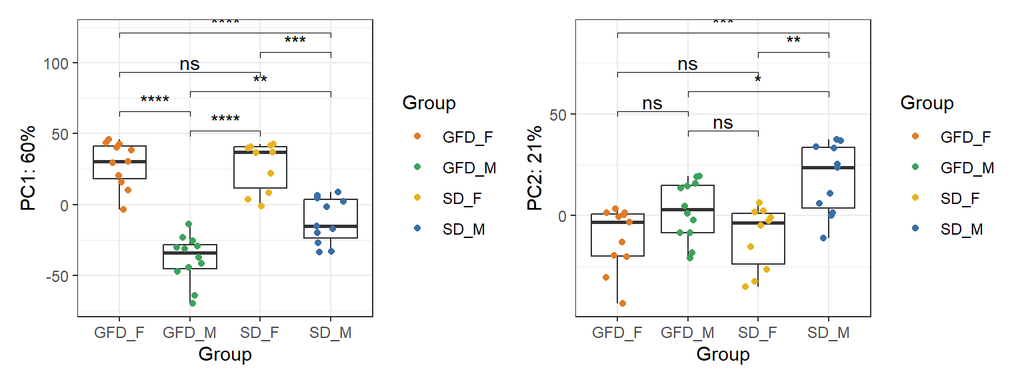

```r
p2 <- ggplot(pca_data, aes(x=Group, y=PC2)) +
  geom_boxplot() +
  geom_jitter(width = 0.2,height = 0,aes(colour = Group)) +
  labs(y = paste0("PC2: ", pv[2], "%"), x = "Group") +
  theme_bw() +
  scale_color_manual(values=group_colours) +
  stat_compare_means(comparisons = my_comparisons,
                     method = "wilcox.test",
                     label = "p.signif")
wrap_plots(p1,p2)
```

## 3.5 PERMANOVA

PERMANOVA tests whether groups of samples differ in their overall expression profile, using distances between samples rather than individual genes. The chunk below:

1. Takes the 2,000 most variable genes on the VST scale and computes Euclidean distances between all pairs of samples.
2. Checks **dispersion homogeneity** with `betadisper()`. PERMANOVA assumes groups have a similar spread; if they differ strongly in spread, a significant PERMANOVA result could reflect differences in variability rather than a shift in the average profile.
3. Runs **PERMANOVA** (`adonis2`) with the same design as DESeq2 (Date + Diet × Sex). Terms are tested sequentially in the order written, so Date is accounted for first. R² is the fraction of total variance attributed to each term, and p-values come from 9,999 random permutations of the sample labels.
4. Runs a second, **date-stratified** PERMANOVA (Diet × Sex, with permutations restricted to within each collection date). This is an alternative way to protect against date effects: samples are only shuffled among animals collected on the same day.

**Open code**

```r
# Build distance matrix from VST (top-variance genes)
# use top-variance genes
m = assay(vsd)
rv    <- matrixStats::rowVars(m)
top   <- order(rv, decreasing = TRUE)[seq_len(min(2000, length(rv)))]
mat   <- t(m[top, ])                                   # samples × genes
cd <- as.data.frame(colData(dds))

# align metadata to the expression matrix
meta  <- cd[match(rownames(mat), cd$SampleIAB), ]
nrow(meta) == nrow(mat)
```

```
[1] TRUE
```

**Open code**

```r
d <- dist(mat)# Euclidean on VST

# Dispersion homogeneity
bd <- betadisper(d, meta$Group)

# if significant -> groups differ in SPREAD, PERMANOVA may be  invalid
anova(bd) %>% kable(
    caption = "Results for test of dispersion homogeneity",
    digits  = 8,
    booktabs = TRUE,
    align = "llcccccc"
  ) %>%
  kable_styling(
    latex_options = c("hold_position"),
    bootstrap_options = c("striped", "hover", "condensed")
  )
```

Results for test of dispersion homogeneity

|  | Df | Sum Sq | Mean Sq | F value | Pr(>F) |
| --- | --- | --- | --- | --- | --- |
| Groups | 3 | 140.3142 | 46.77139 | 0.1494092 | 0.9294646 |
| Residuals | 40 | 12521.6868 | 313.04217 | NA | NA |

**Open code**

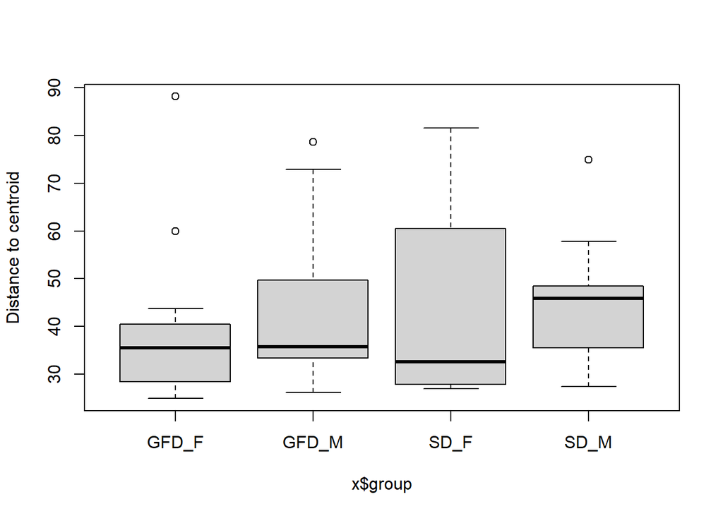

```r
boxplot(bd)             # visualize per-group spread
```

**Open code**

```r
# PERMANOVA — the location test
# Match DESeq2 design: Date + Diet * Sex
set.seed(123)
pmv <- adonis2(d ~ Date + Diet * Sex,
               data = meta,
               by = "terms", # sequential; tests each term in order
               permutations = 9999)
pmv %>%    kable(
    caption = "PERMANOVA 1 result",
    digits  = 8,
    booktabs = TRUE,
    align = "llcccccc"
  ) %>%
  kable_styling(
    latex_options = c("hold_position"),
    bootstrap_options = c("striped", "hover", "condensed")
  )
```

PERMANOVA 1 result

|  | Df | SumOfSqs | R2 | F | Pr(>F) |
| --- | --- | --- | --- | --- | --- |
| Date | 1 | 13128.268 | 0.08288187 | 6.997622 | 0.0030 |
| Diet | 1 | 9391.687 | 0.05929194 | 5.005952 | 0.0086 |
| Sex | 1 | 55138.725 | 0.34810383 | 29.390012 | 0.0001 |
| Diet:Sex | 1 | 7570.611 | 0.04779506 | 4.035283 | 0.0189 |
| Residual | 39 | 73168.063 | 0.46192730 | NA | NA |
| Total | 43 | 158397.355 | 1.00000000 | NA | NA |

**Open code**

```r
# Confound aware
set.seed(123)
pmv2 <- adonis2(d ~ Diet * Sex,
               data = meta,
               strata = meta$Date,
               by = "terms", # sequential; tests each term in order
               permutations = 9999)
pmv2 %>%    kable(
    caption = "PERMANOVA 2 result",
    digits  = 8,
    booktabs = TRUE,
    align = "llcccccc"
  ) %>%
  kable_styling(
    latex_options = c("hold_position"),
    bootstrap_options = c("striped", "hover", "condensed")
  )
```

PERMANOVA 2 result

|  | Df | SumOfSqs | R2 | F | Pr(>F) |
| --- | --- | --- | --- | --- | --- |
| Diet | 1 | 9428.053 | 0.05952153 | 4.175799 | 0.0134 |
| Sex | 1 | 49885.396 | 0.31493831 | 22.094850 | 0.0001 |
| Diet:Sex | 1 | 8772.551 | 0.05538319 | 3.885470 | 0.0178 |
| Residual | 40 | 90311.355 | 0.57015697 | NA | NA |
| Total | 43 | 158397.355 | 1.00000000 | NA | NA |

## 3.6 Clustering

Euclidean distances between all samples are computed on the full VST matrix and shown as a heatmap, with samples hierarchically clustered so that similar samples sit next to each other. The annotation bars show Diet, Sex and Date for each sample, which makes it easy to see which factor the clustering follows. Darker blue means more similar samples.

**Open code**

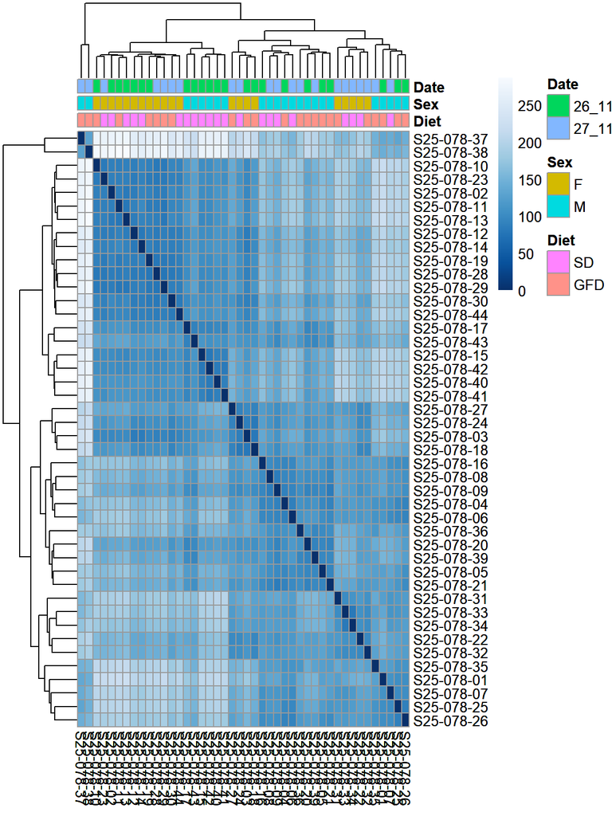

```r
# Sample-to-sample distance heatmap.
sampleDists <- dist(t(assay(vsd)))
p <- pheatmap(as.matrix(sampleDists),
         clustering_distance_rows = sampleDists,
         clustering_distance_cols = sampleDists,
         col = colorRampPalette(rev(brewer.pal(9, "Blues")))(255),
         annotation_col = as.data.frame(colData(dds)[, c("Diet", "Sex", "Date")]))

p
```

## 3.7 A1: dataset control

Number of animals in each Diet × Sex combination.

**Open code**

```r
table(sample_metadata$Diet,sample_metadata$Sex)
```

```
       F  M
  SD  10 11
  GFD 11 12
```

## 3.8 A2: Date + Diet * Sex

**GFD vs SD (diet effect)**

- **IN FEMALES** - the diet effect in females is captured entirely by the main-effect coefficient, because females are the reference (single coef is enough)
- **IN MALES**- there’s no single coefficient for “diet effect in males.” We have to build it by adding the female diet effect plus the male-specific adjustment:

DietGFD.SexM = (DIET_MALES) - (DIET_FEMALES), so then:

DIET_MALES = DIET_FEMALES + DietGFD.SexM

**M vs F (Sex effect)**

- **IN SD** - we have it already in the model: Sex_M_vs_F is effect of sex in reference diet (SD)
- **IN GFD**- SEX_GFD = SEX_SD + DietGFD.SexM

**Open code**

```r
alpha <- 0.05
lfc   <- 1

# ashr: it shrinks single coefficients AND summed contrasts

# GFD vs SD (diet effect)
## in females
res_diet_in_F  <- lfcShrink(dds, coef = "Diet_GFD_vs_SD", type = "ashr")
```

```
using 'ashr' for LFC shrinkage. If used in published research, please cite:
    Stephens, M. (2016) False discovery rates: a new deal. Biostatistics, 18:2.
    https://doi.org/10.1093/biostatistics/kxw041
```

**Open code**

```r
## in males
res_diet_in_M  <- lfcShrink(
  dds, contrast = list(c("Diet_GFD_vs_SD","DietGFD.SexM")),
  type = "ashr")
```

```
using 'ashr' for LFC shrinkage. If used in published research, please cite:
    Stephens, M. (2016) False discovery rates: a new deal. Biostatistics, 18:2.
    https://doi.org/10.1093/biostatistics/kxw041
```

**Open code**

```r
# M vs F (sex effect)

## IN SD
res_sex_in_SD  <- lfcShrink(dds, coef = "Sex_M_vs_F", type = "ashr")
```

```
using 'ashr' for LFC shrinkage. If used in published research, please cite:
    Stephens, M. (2016) False discovery rates: a new deal. Biostatistics, 18:2.
    https://doi.org/10.1093/biostatistics/kxw041
```

**Open code**

```r
## IN GFD
res_sex_in_GFD <- lfcShrink(
  dds, contrast = list(c("Sex_M_vs_F","DietGFD.SexM")),
  type = "ashr")
```

```
using 'ashr' for LFC shrinkage. If used in published research, please cite:
    Stephens, M. (2016) False discovery rates: a new deal. Biostatistics, 18:2.
    https://doi.org/10.1093/biostatistics/kxw041
```

**Open code**

```r
# Interaction: does the diet effect depend on sex?
res_int <- lfcShrink(dds, coef = "DietGFD.SexM", type = "ashr")
```

```
using 'ashr' for LFC shrinkage. If used in published research, please cite:
    Stephens, M. (2016) False discovery rates: a new deal. Biostatistics, 18:2.
    https://doi.org/10.1093/biostatistics/kxw041
```

**Open code**

```r
# Summarise significant-gene counts
summarise_res <- function(res, sym,name) {
  sig <- subset(as.data.frame(res),
                !is.na(padj) & padj < alpha & abs(log2FoldChange) >= lfc)
  message(sprintf("%-24s : %d significant genes", name, nrow(sig)))
  sig <- sig %>%
  rownames_to_column("gene_id") %>%     # name the key column correctly
  left_join(sym, by = "gene_id")

  write.xlsx(sig,paste0("../Results/",name,".xlsx"),rownames=FALSE)
  return(sig)
}

# keeps only the columns we pick and collapses the result to unique combinations, throwing away the transcript-level duplication.
sym <- distinct(tx2gene, gene_id, gene_name)   # lookup

# summary
sig_diet_F  <- summarise_res(res_diet_in_F,sym,  "Diet effect in females")
```

```
Diet effect in females   : 3 significant genes
```

**Open code**

```r
sig_diet_M  <- summarise_res(res_diet_in_M,sym,  "Diet effect in males")
```

```
Diet effect in males     : 1286 significant genes
```

**Open code**

```r
sig_sex_SD  <- summarise_res(res_sex_in_SD,sym,  "Sex effect in SD")
```

```
Sex effect in SD         : 564 significant genes
```

**Open code**

```r
sig_sex_GFD <- summarise_res(res_sex_in_GFD,sym, "Sex effect in GFD")
```

```
Sex effect in GFD        : 6129 significant genes
```

**Open code**

```r
sig_int     <- summarise_res(res_int,sym,        "Diet x Sex interaction")
```

```
Diet x Sex interaction   : 75 significant genes
```

**Comprehensive summary**

Now, we want also mean normalized counts, TPM in both groups for all genes

`summarise_all_res()` (from the helper functions) builds a complete table for **all** genes, not only the significant ones: shrunk log2 fold change, p-values, and the mean normalized counts and mean TPM in each of the two compared groups. Having group means next to fold changes makes it easy to judge whether a change is biologically meaningful (e.g. a large fold change from almost zero expression).

**Open code**

```r
# summary
diet_in_F <- summarise_all_res(res_diet_in_F, sym, "diet_in_F",
                           txi, dds, sample_metadata,
                           groups = c("SD_F", "GFD_F"))

diet_in_M <- summarise_all_res(res_diet_in_M, sym, "diet_in_M",
                           txi, dds, sample_metadata,
                           groups = c("SD_M", "GFD_M"))


sex_in_SD <- summarise_all_res(res_sex_in_SD, sym, "sex_in_SD",
                           txi, dds, sample_metadata,
                           groups = c("SD_F", "SD_M"))

sex_in_GFD <- summarise_all_res(res_sex_in_GFD, sym, "sex_in_GFD",
                           txi, dds, sample_metadata,
                           groups = c("GFD_F", "GFD_M"))

sex_diet_int <- summarise_all_res(res_int, sym, "sex_diet_int",
                           txi, dds, sample_metadata,
                           groups = c("GFD_F", "GFD_M","SD_F", "SD_M"))
```

### 3.8.1 Visualization

Volcano plots of the diet effect in females and in males. Each point is a gene: the x-axis is the shrunk log2 fold change (GFD vs SD) and the y-axis is −log10(padj), so genes higher up are more significant. Fold changes beyond ±10 are clipped to the plot edge, and both panels share the same x- and y-axis ranges so that the two sexes can be compared directly.

**Open code**

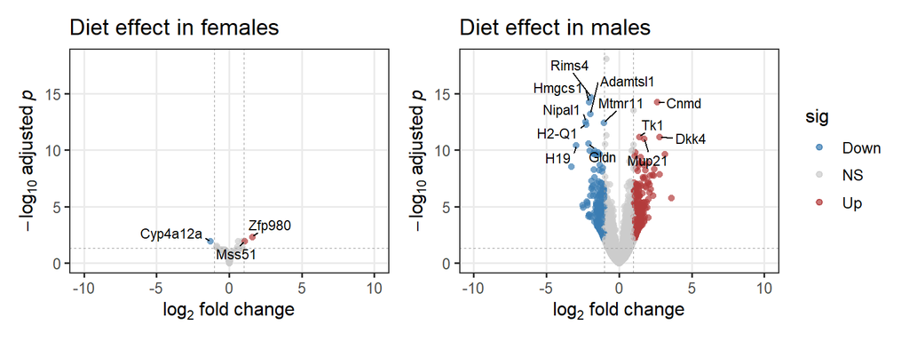

```r
# shared clip so both panels use the SAME x-axis
shared_clip <- 10   # anything beyond is low-count noise

p_diet_F <- make_volcano(
  res_diet_in_F,
  "Diet effect in females",
  clip = shared_clip)

p_diet_M <- make_volcano(
  res_diet_in_M,
  "Diet effect in males",
  clip = shared_clip)

# matched y-axis too, so panels are truly comparable
ymax <- max(-log10(na.omit(c(res_diet_in_F$padj, res_diet_in_M$padj))))
p_diet_F <- p_diet_F + ylim(0, ymax)
p_diet_M <- p_diet_M + ylim(0, ymax)

(p_diet_F | p_diet_M) + plot_layout(guides = "collect")
```

**Open code**

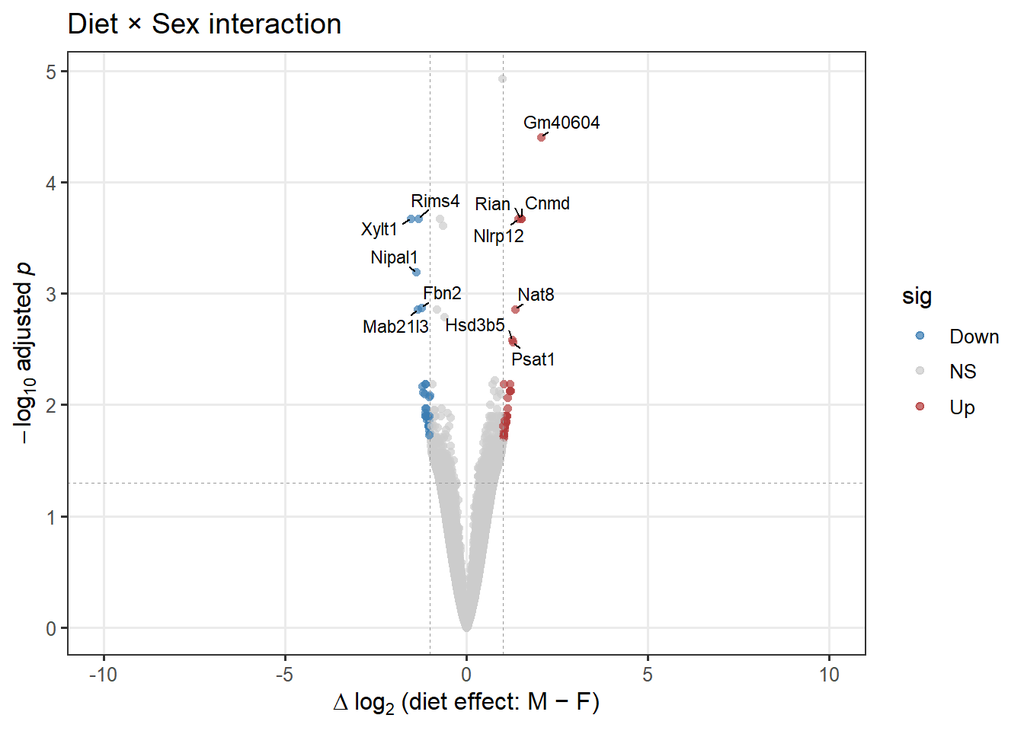

```r
p_int <- make_volcano(
  res_int, "Diet × Sex interaction",
  xlab = expression(Delta~log[2]~"(diet effect: M − F)"),
  clip = shared_clip
)
p_int
```

**Open code**

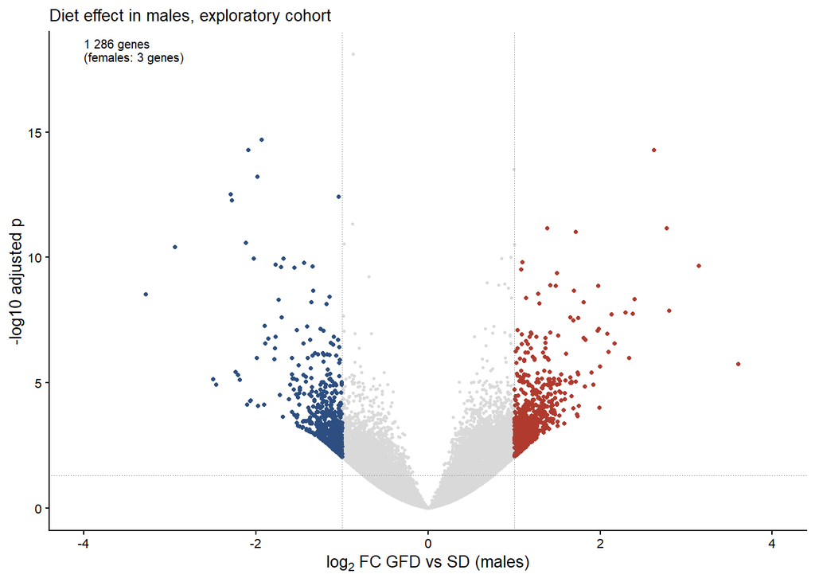

```r
f_5b <- make_volcano_publication(
  res_diet_in_M,
  title = "Diet effect in males, exploratory cohort",
  xlab=expression(log[2]~FC~"GFD vs SD (males)"),
  clip = 4
)
f_5b
```

**Open code**

```r
save(f_5b,file = "../Results/figures/F5B.RData")
```

**NoteInterpretation**

Splitting the diet effect by sex reveals a striking asymmetry (padj < 0.05, |log2FC| ≥ 1):

- 3 genes respond to diet in females
- 1286 genes respond to diet in males

The sex difference is itself diet-dependent: 564 genes differ by sex under SD, but 6129 differ by sex under GFD (about 11×), i.e. diet strongly amplifies sexual dimorphism.

The formal interaction term flags 75 genes as significantly sex-dependent in their diet response. The consistent message is that essentially all of the diet response lives on the male side, which makes males the informative group for the panel and pathway analyses that follow.

**Caveat:** GFD males were collected last (see A3), and the male diet genes drift with collection order more than background genes do. Part of the male-specific response may therefore reflect time of collection rather than diet.

## 3.9 Gene panel

Several analyses below use curated gene panels: small sets of marker genes that represent a biological program. The table lists the genes and their roles for panels 3a–4 (glucocorticoid targets, fasting, lipogenesis, circadian clock); the full list of panels, including the sex-specific liver programs (1a–1c), immediate-early/stress genes (2) and liver-damage panels (5–8), is defined in the code below.

| Panel | Gene | Role |
| --- | --- | --- |
| **3a — GC targets** | Tsc22d3 (GILZ) | Canonical glucocorticoid-induced anti-inflammatory gene |
|  | Fkbp5 | Co-chaperone; one of the most reliable GC-response markers |
|  | Klf15 | GC-induced TF linking steroids to amino-acid/lipid metabolism |
|  | Sds | GC-inducible amino-acid catabolism enzyme |
|  | Zbtb16 (PLZF) | GC-responsive TF tied to metabolism and immunity |
|  | Per1 | Clock gene that is also directly GC-inducible |
| **3b — Fasting** | Fgf21 | Fasting-induced hepatokine driving the starvation response |
|  | Hmgcs2 | Rate-limiting enzyme of ketone-body production |
|  | Cpt1a | Controls mitochondrial fatty-acid import for β-oxidation |
|  | Ppargc1a (PGC-1α) | Master coactivator of fasting/oxidative metabolism |
|  | Pck1 (PEPCK) | Rate-limiting gluconeogenesis enzyme |
|  | G6pc1 | Final step of hepatic glucose output |
|  | Angptl4 | Fasting-induced regulator of lipoprotein lipase |
|  | Slc25a20 | Carnitine/acylcarnitine carrier feeding β-oxidation |
| **3c — Lipogenesis** | Fasn | Fatty-acid synthase, core de novo lipogenesis enzyme |
|  | Scd1 | Desaturates saturated → monounsaturated fatty acids |
|  | Elovl6 | Elongates fatty-acid chains during synthesis |
|  | Acaca (ACC1) | Committed, rate-limiting step of fatty-acid synthesis |
|  | Srebf1 (SREBP-1c) | Master TF driving lipogenic genes |
|  | Mlxipl (ChREBP) | Glucose-sensing TF for lipogenesis |
|  | Hmgcs1 | Cytosolic HMG-CoA synthase (mevalonate pathway) |
|  | Hmgcr | Rate-limiting cholesterol synthesis enzyme (statin target) |
|  | Sqle | Key regulatory step in cholesterol biosynthesis |
|  | Ldlr | LDL receptor; SREBP-controlled cholesterol uptake |
|  | Insig1 | Feedback regulator restraining SREBP activation |
| **4 — Circadian** | Bmal1 (Arntl) | Central positive-limb clock TF |
|  | Npas2 | CLOCK paralog partnering BMAL1 |
|  | Nr1d1 / Nr1d2 (REV-ERBα/β) | Nuclear receptors of the repressive stabilizing loop |
|  | Per1 / Per2 / Per3 | Period genes of the negative-feedback repressor limb |
|  | Cry1 / Cry2 | Cryptochrome repressors that partner with PER |
|  | Dbp / Tef / Hlf | PAR-bZIP clock-output transcription factors |
|  | Nfil3 (E4BP4) | Repressor opposing the PAR-bZIP factors |
|  | Ciart (CHRONO) | Additional BMAL1 repressor fine-tuning the clock |

**Building panels**

For the panel analyses, the VST is recomputed with `blind = FALSE`. Here the design is used when estimating how variance depends on expression level. This is recommended when the transformed values are used for downstream quantitative comparisons between groups, since large group differences would otherwise inflate the variance estimates. `m` is the resulting gene × sample expression matrix.

**Open code**

```r
vsd <- vst(dds, blind = FALSE)
m  <- assay(vsd)  # genes x samples
```

**Open code**

```r
panels_sym <- list(
  `1a_male_liver`   = c("Hsd3b5","Cyp4a12a","Cyp4a12b","Cyp2d9","Cyp7b1","Slco1a1",
                        "Elovl3","Nudt7","Ugt2b1","Bcl6"),
  `1b_female_liver` = c("Cyp2b9","Cyp3a41a","Cyp3a44","Cyp2a4","Sult3a1","Sult2a1",
                        "Fmo3","A1bg","Nnmt","Cux2"),
  `1c_GH_STAT5`     = c("Ghr","Stat5b","Socs2","Cish","Igf1","Igfals","Socs3"),
  `2_IEG_stress`    = c("Fos","Fosb","Jun","Junb","Jund","Egr1","Atf3","Dusp1",
                        "Nr4a1","Hspa1a","Hspa1b"),
  `3a_GC_targets`   = c("Tsc22d3","Fkbp5","Klf15","Sds","Zbtb16","Per1"),
  `3b_fasting`      = c("Fgf21","Hmgcs2","Cpt1a","Ppargc1a","Pck1","G6pc1",
                        "Angptl4","Slc25a20"),
  `3c_lipogenesis`  = c("Fasn","Scd1","Elovl6","Acaca","Srebf1","Mlxipl","Hmgcs1",
                        "Hmgcr","Sqle","Ldlr","Insig1"),
  `4_circadian`     = c("Bmal1","Npas2","Nr1d1","Nr1d2","Per1","Per2","Per3","Cry1",
                        "Cry2","Dbp","Tef","Hlf","Nfil3","Ciart"),
  `5_fibrosis`      = c("Col1a1","Col1a2","Col3a1","Acta2","Timp1","Timp2","Lox",
                        "Pdgfrb","Tgfb1","Sparc"),
  `6_ductular`      = c("Krt19","Krt7","Epcam","Sox9","Spp1","Cldn7","Hnf1b"),
  `7_inflammation`  = c("Ccl2","Ccl5","Cxcl1","Cxcl9","Tnf","Il1b","Il6","Lcn2",
                        "Saa1","Saa2","Adgre1","Itgam","Mmp12"),
  `8_cholestasis`   = c("Cyp7a1","Cyp8b1","Cyp27a1","Cyp2c70","Cyp2a12","Nr0b2",
                        "Nr1h4","Slc10a1","Abcb11","Abcc3","Abcc4","Slc51a","Slc51b",
                        "Baat","Abcb4")
)

# "Mup family "
mup_syms <- grep("^Mup[0-9]", sym$gene_name, value = TRUE) %>% unique()
panels_sym[["1a_male_liver"]] <- c(panels_sym[["1a_male_liver"]], mup_syms)
cat("Mup family notation found in :", length(mup_syms), "genes\n")
```

```
Mup family notation found in : 22 genes
```

**Open code**

```r
# map with gene id and gene name
sym2id <- function(s) sym$gene_id[match(s, sym$gene_name)]

# QC / coverage-check step: for each gene panel
# it counts how many of requested genes actually made it into expression data,
# and reports which genes dropped out and why.
coverage <- lapply(names(panels_sym), function(nm) {
  s  <- panels_sym[[nm]]
  id <- sym2id(s)
  in_annot <- !is.na(id)
  in_data  <- in_annot & id %in% rownames(m)
  data.frame(
    panel             = nm,
    requested         = length(s),
    in_data           = sum(in_data),
    not_in_annotation = paste(s[!in_annot],            collapse = ", "),
    filtered_lowcount = paste(s[in_annot & !in_data],  collapse = ", ")
  )
}) %>% dplyr::bind_rows()

coverage %>%
  kable(
    caption = "Genes detected in our RNAseq dataset",
    digits  = 8,
    booktabs = TRUE,
    align = "llcccccc"
  ) %>%
  kable_styling(
    latex_options = c("hold_position"),
    bootstrap_options = c("striped", "hover", "condensed")
  )
```

Genes detected in our RNAseq dataset

| panel | requested | in_data | not_in_annotation | filtered_lowcount |
| --- | --- | --- | --- | --- |
| 1a_male_liver | 32 | 32 |  |  |
| 1b_female_liver | 10 | 10 |  |  |
| 1c_GH_STAT5 | 7 | 7 |  |  |
| 2_IEG_stress | 11 | 11 |  |  |
| 3a_GC_targets | 6 | 6 |  |  |
| 3b_fasting | 8 | 8 |  |  |
| 3c_lipogenesis | 11 | 11 |  |  |
| 4_circadian | 14 | 14 |  |  |
| 5_fibrosis | 10 | 10 |  |  |
| 6_ductular | 7 | 7 |  |  |
| 7_inflammation | 13 | 13 |  |  |
| 8_cholestasis | 15 | 15 |  |  |

**Open code**

```r
# case-insensitive
missing_all <- unique(unlist(lapply(panels_sym, function(s) s[is.na(sym2id(s))])))
if (length(missing_all)) {
  cat("\ncase-insensitive:\n")
  for (g in missing_all) {
    hit <- grep(paste0("^", g, "$"), sym$gene_name, ignore.case = TRUE, value = TRUE)
    if (length(hit)) cat(sprintf("  %-12s -> %s\n", g, paste(hit, collapse = ", ")))
  }
}

# final panels
panels <- lapply(panels_sym, function(s) {
  id <- sym2id(s); unique(id[!is.na(id) & id %in% rownames(m)])
})
```

## 3.10 A3: Time gradient within groups

Checks whether collection order is balanced across the four groups. The boxplot shows the order positions of each group and the Kruskal–Wallis test asks whether they differ. If one group had been collected systematically earlier or later, time-of-day effects would be confounded with that group.

**Open code**

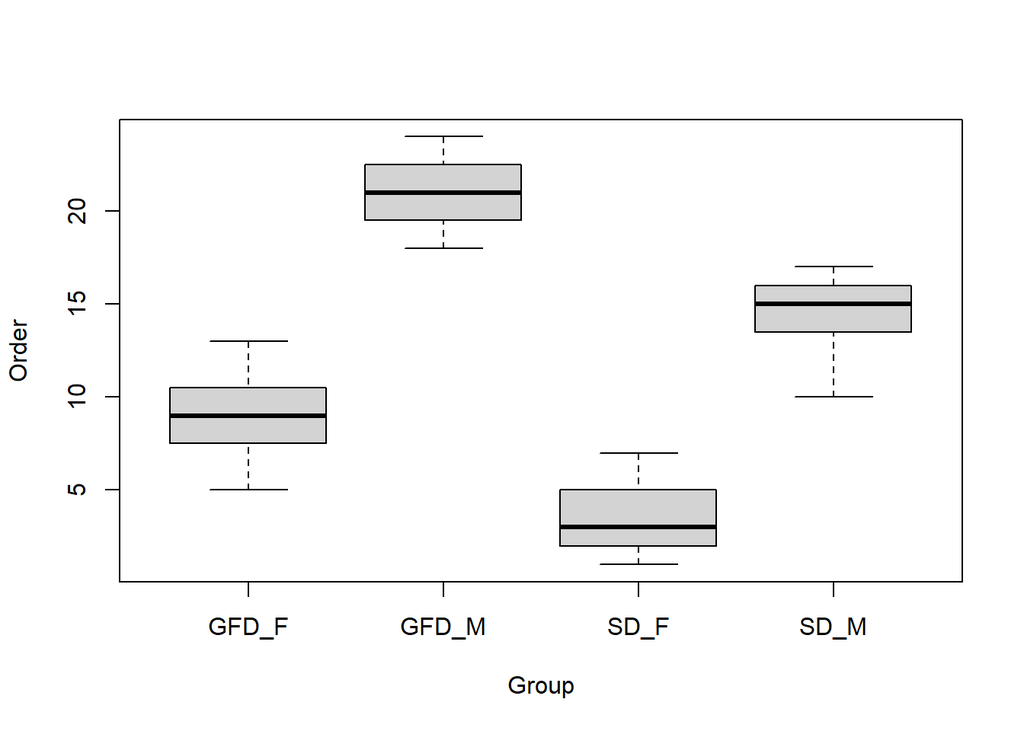

```r
# prepare sample metadata
cd <- as.data.frame(colData(dds))
cd$Order <- as.numeric(cd$Order)

# Are Diet/Sex/Group distributed evenly across Order?
boxplot(Order ~ Group, data = cd)
```

**Open code**

```r
kruskal.test(Order ~ Group, data = cd)
```

```
    Kruskal-Wallis rank sum test

data:  Order by Group
Kruskal-Wallis chi-squared = 39.079, df = 3, p-value = 1.67e-08
```

**WarningInterpretation**

Collection order is **not** balanced: the groups were collected in blocks, SD_F first, then GFD_F, SD_M and GFD_M last. Group is therefore strongly confounded with time of collection (time of day and time since the last meal). The within-group drift tests below can only detect trends *inside* a group; they cannot separate a between-group difference from a time-of-collection difference.

One point in favour of a real diet effect: the order gap between SD and GFD is similar in females and in males, yet only males respond to diet. This argues against a simple linear time effect, but it cannot exclude a non-linear one (e.g. fasting effects that appear only late in the session).

### 3.10.1 All genes

Samples were collected in a sequence (`Order`), and time of collection can affect liver expression, both through the circadian clock and through handling. This section checks whether expression drifts with collection order **within** groups, i.e. beyond what Diet and Sex explain.

For every gene, `order_drift()` (helper function) fits expression ~ Group + Order on the VST scale and reports the Order slope, its t-statistic and a BH-adjusted p-value. A significant slope means the gene changes steadily with collection order among animals of the same group. The chunk prints the number of such genes and the top hits.

**Open code**

```r
vsd_a3 <- vst(dds, blind = FALSE)
m      <- assay(vsd_a3)  # genes x samples

# calculate order drift
# ~ Group + Order
drift <- order_drift(m, cd)

# significance
sig_order <- subset(drift, padj < 0.05)

# show results
cat(nrow(sig_order), "of", nrow(drift),
    "genes have within-group order drift (padj<0.05)\n")
```

```
0 of 25981 genes have within-group order drift (padj<0.05)
```

**Open code**

```r
# genes with drift
head(sig_order[order(sig_order$padj), c("gene_name","slope","t","padj")]) %>%
  kable(
    caption = "Genes with significant drift within-groups",
    booktabs = TRUE,
    align = "llcccccc"
  ) %>%
  kable_styling(
    latex_options = c("hold_position"),
    bootstrap_options = c("striped", "hover", "condensed")
  )
```

Genes with significant drift within-groups

[output not shown]

**Visualization**

**Open code**

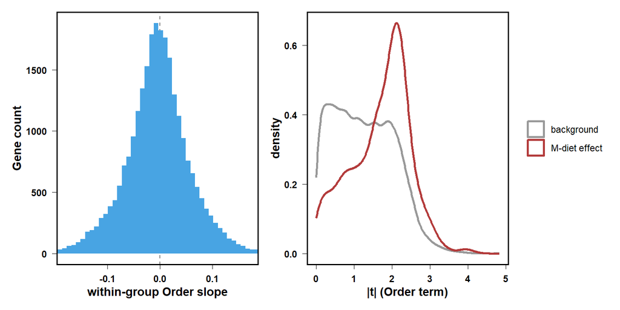

```r
plot_df <- drift %>%
  dplyr::mutate(diet_M = gene_id %in% sig_diet_M$gene_id)

# the distribution of order-drift slopes across all genes
# a symmetric bump centered on zero means most genes have
# no systematic order trend
p1 <- ggplot(drift, aes(slope)) +
  geom_vline(xintercept = 0, linetype = "dashed", colour = "grey50") +
  geom_histogram(bins = 80, fill = "#48a4e3") +
  coord_cartesian(xlim = quantile(drift$slope, c(.005, .995), na.rm = TRUE)) +
  labs(x = "within-group Order slope", y = "Gene count")

# Do male-specific diet genes stronger order drift than background?
# the grey curve is all the background genes, the red curve is just the male-diet genes
# We are looking for whether the red curve sits to the right of the grey curve.
# Red overlapping / left of grey → the male-diet genes drift with order no more than typical genes.
# Red to the right of grey → the male-diet genes drift with order more than typical genes (possible order artifact).
p2 <- ggplot(plot_df, aes(abs(t), colour = diet_M)) +
  geom_density(linewidth = 0.9) +
  scale_colour_manual(values = c("grey60", "#B33B3B"),
                      labels = c("background", "M-diet effect"), name = NULL) +
  labs(x = "|t| (Order term)", y = "density")

(ggtheme(p1) | ggtheme(p2)) + patchwork::plot_layout(guides = "collect")
```

**Left panel (p1)** Looks healthy. The slope distribution is a clean, roughly symmetric bump centered on zero. Most genes show little to no systematic trend with Order, and there’s no global shift off zero. So there isn’t a coherent, genome-wide directional drift - the technical gradient isn’t dominating everything.

**Right panel (p2)** The red curve (M-diet genes) is clearly shifted to the right of the grey (background). Background |t| peaks around 0.5–1.5 with most mass below 2, while the M-diet curve peaks sharply around 2 and has substantially more mass in the 2–3 range. In plain terms: our significant male-diet genes have systematically stronger order-drift than typical genes. Two formal tests of the visual impression in the right panel: the Kolmogorov–Smirnov test asks whether the two |t| distributions differ in shape or location, and the Wilcoxon test asks whether their medians differ.

**Open code**

```r
ks.test(abs(plot_df$t[plot_df$diet_M]),
        abs(plot_df$t[!plot_df$diet_M]))          # distribution shift
```

```
    Asymptotic two-sample Kolmogorov-Smirnov test

data:  abs(plot_df$t[plot_df$diet_M]) and abs(plot_df$t[!plot_df$diet_M])
D = 0.2718, p-value < 2.2e-16
alternative hypothesis: two-sided
```

**Open code**

```r
wilcox.test(abs(t) ~ diet_M, data = plot_df)      # median shift
```

```
    Wilcoxon rank sum test with continuity correction

data:  abs(t) by diet_M
W = 10758802, p-value < 2.2e-16
alternative hypothesis: true location shift is not equal to 0
```

Both tests confirm that the male-diet genes have stronger within-group order drift than background genes. No single gene reaches significance for drift, so this is a population-level signal, but together with the unbalanced collection order it means the male diet response should be interpreted with the time-of-collection caveat in mind.

### 3.10.2 Panel score

The drift test is repeated at the panel level. Each gene is first z-scored across samples (centered to mean 0 and scaled to standard deviation 1), so that genes with different expression levels contribute equally. A panel score is then the mean z-score of the panel’s genes in each sample: one number per sample that summarizes how active the program is. Each panel score is tested against Order, again within groups (score ~ Group + Order), with BH correction across panels.

**Open code**

```r
# z-score each gene across samples
z <- t(scale(t(m)))

# loop over panels and build a panel score
# For each panel, it grabs that panel's genes and computes sc
# sc = the mean z-score across the panel's genes, for each sample.
# So sc is one number per sample — a summary "how active is this panel in this sample."

score_tab <- lapply(names(panels), function(nm) {
  ids <- panels[[nm]]; if (length(ids) < 2) return(NULL)

  # the mean z-score across the panel's genes
  sc <- colMeans(z[ids, , drop = FALSE], na.rm = TRUE) # panel score per sample

  # test the panel score against Order
  co <- summary(lm(sc ~ Group + Order,
                   data = cbind(cd, sc = sc)))$coefficients["Order", ]
  data.frame(panel = nm, n = length(ids),
             slope = co[1], se = co[2], t = co[3], p = co[4])
}) %>%  dplyr::bind_rows()


score_tab$padj <- p.adjust(score_tab$p, "BH")
score_tab %>%
  kable(
    caption = "Gene panels' drift within-groups",
    booktabs = TRUE,
    align = "llcccccc"
  ) %>%
  kable_styling(
    latex_options = c("hold_position"),
    bootstrap_options = c("striped", "hover", "condensed")
  )
```

Gene panels' drift within-groups

|  | panel | n | slope | se | t | p | padj |
| --- | --- | --- | --- | --- | --- | --- | --- |
| Estimate...1 | 1a_male_liver | 32 | 0.0135378 | 0.0189611 | 0.7139747 | 0.4794943 | 0.7555754 |
| Estimate...2 | 1b_female_liver | 10 | 0.0260426 | 0.0149672 | 1.7399826 | 0.0897491 | 0.3679433 |
| Estimate...3 | 1c_GH_STAT5 | 7 | 0.0071456 | 0.0302755 | 0.2360195 | 0.8146527 | 0.8887120 |
| Estimate...4 | 2_IEG_stress | 11 | 0.0363151 | 0.0446107 | 0.8140430 | 0.4205631 | 0.7555754 |
| Estimate...5 | 3a_GC_targets | 6 | -0.0213299 | 0.0421897 | -0.5055702 | 0.6160040 | 0.7555754 |
| Estimate...6 | 3b_fasting | 8 | -0.0043431 | 0.0321434 | -0.1351161 | 0.8932150 | 0.8932150 |
| Estimate...7 | 3c_lipogenesis | 11 | -0.0201512 | 0.0414584 | -0.4860578 | 0.6296462 | 0.7555754 |
| Estimate...8 | 4_circadian | 14 | -0.0604896 | 0.0415361 | -1.4563149 | 0.1533097 | 0.3679433 |
| Estimate...9 | 5_fibrosis | 10 | -0.0568990 | 0.0365438 | -1.5570081 | 0.1275473 | 0.3679433 |
| Estimate...10 | 6_ductular | 7 | -0.0754442 | 0.0479519 | -1.5733312 | 0.1237207 | 0.3679433 |
| Estimate...11 | 7_inflammation | 13 | 0.0456657 | 0.0296524 | 1.5400327 | 0.1316278 | 0.3679433 |
| Estimate...12 | 8_cholestasis | 15 | 0.0125557 | 0.0207285 | 0.6057219 | 0.5482086 | 0.7555754 |

### 3.10.3 Circadian genes

The circadian panel is examined gene by gene. The plot shows each clock gene’s expression against collection order, with a separate trend line for each group and point shape showing the collection date. If collection spanned different times of day, clock genes would be expected to change steadily with Order.

**Open code**

```r
clock_ids <- panels[["4_circadian"]]

# vst expression for each panel gene for each sample
clock_long <- as.data.frame(t(m[clock_ids, , drop = FALSE])) %>%
  rownames_to_column("SampleID") %>%
  dplyr::mutate(Order = cd$Order,
                Group = cd$Group,
                Date = cd$Date) %>%
  tidyr::pivot_longer(
    dplyr::all_of(clock_ids),
    names_to = "gene_id", values_to = "expr") %>%
  dplyr::left_join(sym, by = "gene_id")

# plot
p_clock <- ggplot(clock_long, aes(Order, expr, colour = Group, shape=Date)) +
  geom_point(size = 1.4, alpha = 0.75) +
  geom_smooth(method = "lm", se = FALSE, linewidth = 0.6) +
  facet_wrap(~ gene_name, scales = "free_y") + # for each gene
  scale_colour_manual(values = group_colours) +
  labs(x = "Order", y = "vst expression",
       title = "Circadian genes vs. order (slope within group)")
```

**Open code**

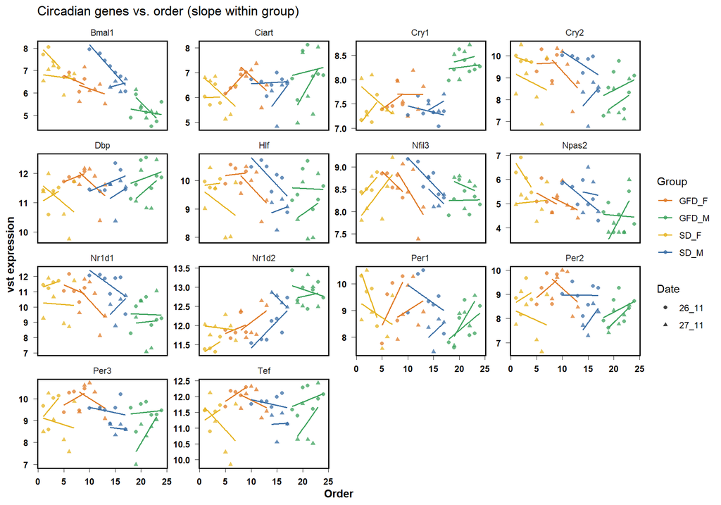

```r
ggtheme(p_clock)
```

Order-drift statistics (from `order_drift()` above) for the clock genes.

**Open code**

```r
drift %>% dplyr::filter(gene_id %in% clock_ids) %>%
  dplyr::left_join(sym, by = "gene_id") %>%
  dplyr::select(gene_name.x, slope, t, p, padj) %>%
  kable(
    caption = "Circadian gene's drift",
    booktabs = TRUE,
    align = "llcccccc"
  ) %>%
  kable_styling(
    latex_options = c("hold_position"),
    bootstrap_options = c("striped", "hover", "condensed")
  )
```

Circadian gene's drift

| gene_name.x | slope | t | p | padj |
| --- | --- | --- | --- | --- |
| Hlf | -0.1325010 | -2.3949789 | 0.0215221 | 0.2405689 |
| Cry1 | 0.0086599 | 0.4242517 | 0.6737134 | 0.8198093 |
| Nr1d1 | -0.1861821 | -2.1566058 | 0.0372612 | 0.2405689 |
| Per1 | -0.0299187 | -0.4590182 | 0.6487693 | 0.8034929 |
| Nr1d2 | 0.0676730 | 2.5259901 | 0.0157095 | 0.2405689 |
| Tef | -0.0407288 | -0.9674871 | 0.3392624 | 0.5615683 |
| Npas2 | -0.0671532 | -1.3286369 | 0.1916899 | 0.4106105 |
| Per3 | -0.0284531 | -0.5205450 | 0.6056267 | 0.7747567 |
| Ciart | 0.0037842 | 0.0681439 | 0.9460192 | 0.9749645 |
| Bmal1 | -0.1464743 | -4.1996049 | 0.0001501 | 0.2405689 |
| Per2 | -0.0255907 | -0.4700531 | 0.6409350 | 0.7980865 |
| Nfil3 | -0.0524748 | -1.7868419 | 0.0817379 | 0.2752638 |
| Dbp | -0.0171800 | -0.3993463 | 0.6918166 | 0.8313254 |
| Cry2 | -0.1182119 | -1.6706276 | 0.1028027 | 0.3036261 |

### 3.10.4 Panels 3-4

Order-drift results for individual genes of the panels most likely to respond to time of collection and feeding state (glucocorticoid targets, fasting, lipogenesis), sorted by adjusted p-value.

**Open code**

```r
panel_ids <- unlist(panels[c("3a_GC_targets","3b_fasting",
                             "3c_lipogenesis")])

panel_drift <- drift %>%
  dplyr::filter(gene_id %in% panel_ids) %>%
  dplyr::left_join(
    tibble::enframe(rep(names(panels), lengths(panels)),
                    name = NULL, value = "panel") %>%
      dplyr::mutate(gene_id = unlist(panels)),
    by = "gene_id"
  ) %>%
  dplyr::select(panel, gene_name, slope, t, p, padj) %>%
  dplyr::arrange(padj)

panel_drift %>%
  kable(
    caption = "Drifts for selected panels",
    booktabs = TRUE,
    align = "llcccccc"
  ) %>%
  kable_styling(
    latex_options = c("hold_position"),
    bootstrap_options = c("striped", "hover", "condensed")
  )
```

Drifts for selected panels

| panel | gene_name | slope | t | p | padj |
| --- | --- | --- | --- | --- | --- |
| 3b_fasting | Angptl4 | 0.1402802 | 2.7417667 | 0.0091774 | 0.2405689 |
| 3c_lipogenesis | Mlxipl | -0.1310548 | -2.1328940 | 0.0392829 | 0.2405689 |
| 3c_lipogenesis | Insig1 | 0.0837170 | 2.1208590 | 0.0403456 | 0.2406145 |
| 3a_GC_targets | Zbtb16 | -0.1592994 | -2.0435678 | 0.0477929 | 0.2435607 |
| 3b_fasting | Cpt1a | -0.1393433 | -1.9654769 | 0.0565090 | 0.2493833 |
| 3a_GC_targets | Klf15 | 0.0730861 | 1.8583017 | 0.0706860 | 0.2625438 |
| 3b_fasting | Ppargc1a | -0.0411862 | -1.8436753 | 0.0728384 | 0.2649699 |
| 3c_lipogenesis | Ldlr | -0.1083175 | -1.7877990 | 0.0815807 | 0.2749804 |
| 3c_lipogenesis | Acaca | -0.1471038 | -1.7802028 | 0.0828349 | 0.2768731 |
| 3a_GC_targets | Fkbp5 | -0.0466165 | -1.2004414 | 0.2372089 | 0.4616201 |
| 3c_lipogenesis | Srebf1 | -0.0583969 | -1.1922952 | 0.2403498 | 0.4648994 |
| 3c_lipogenesis | Hmgcr | 0.0535997 | 1.1657661 | 0.2507892 | 0.4760891 |
| 3b_fasting | Fgf21 | 0.0577868 | 1.0669274 | 0.2925650 | 0.5169613 |
| 3b_fasting | Pck1 | -0.0598620 | -0.8233762 | 0.4153008 | 0.6304766 |
| 3b_fasting | Hmgcs2 | -0.0209571 | -0.8144375 | 0.4203398 | 0.6344857 |
| 3b_fasting | G6pc1 | 0.0563865 | 0.6455754 | 0.5223347 | 0.7141491 |
| 3c_lipogenesis | Fasn | -0.0564788 | -0.6104362 | 0.5451140 | 0.7316908 |
| 3c_lipogenesis | Sqle | 0.0277212 | 0.5688749 | 0.5727027 | 0.7515982 |
| 3c_lipogenesis | Hmgcs1 | -0.0285046 | -0.5113660 | 0.6119780 | 0.7784098 |
| 3a_GC_targets | Per1 | -0.0299187 | -0.4590182 | 0.6487693 | 0.8034929 |
| 4_circadian | Per1 | -0.0299187 | -0.4590182 | 0.6487693 | 0.8034929 |
| 3b_fasting | Slc25a20 | 0.0080385 | 0.4487029 | 0.6561293 | 0.8085355 |
| 3c_lipogenesis | Elovl6 | 0.0142477 | 0.3237616 | 0.7478484 | 0.8652409 |
| 3a_GC_targets | Sds | -0.0074238 | -0.1386838 | 0.8904136 | 0.9457824 |
| 3c_lipogenesis | Scd1 | 0.0067447 | 0.1060007 | 0.9161252 | 0.9605266 |
| 3a_GC_targets | Tsc22d3 | -0.0046562 | -0.0894724 | 0.9291644 | 0.9673297 |

## 3.11 Panel tests

**Open code**

```r
program_panels <- names(panels_sym)

# score = mean z-score of gene panels for each samples
scores <- sapply(program_panels, function(nm) {
   colMeans(z[panels[[nm]], , drop = FALSE], na.rm = TRUE)
})

colnames(scores) <- program_panels

# masculinization index:
# male-female program (1 axis, direct feminization test)
scores <- cbind(scores,
                masc_index = scores[, "1a_male_liver"] - scores[, "1b_female_liver"])

test_program <- function(sc, name, cd) {
  fit <- lm(sc ~ Diet * Sex + Date, data = cbind(cd, sc = sc))
  emm <- emmeans(fit, ~ Diet * Sex)
  # cell order in emm: SD_F, GFD_F, SD_M, GFD_M  (check with print(emm))

  ctr <- list(
    diet_in_F   = c(-1,  1,  0, 0),   # GFD_F - SD_F
    diet_in_M   = c( 0,  0, -1, 1),   # GFD_M - SD_M
    sex_in_SD   = c(-1,  0,  1, 0),   # SD_M  - SD_F
    sex_in_GFD  = c( 0, -1,  0, 1),   # GFD_M - GFD_F
    interaction = c( 1, -1, -1, 1)    # (GFD_M - SD_M) - (GFD_F - SD_F)
  )

  res <- summary(contrast(emm, method = ctr, adjust = "none"),
                 infer = TRUE, level = 0.95)

  data.frame(
    Panel      = name,
    Contrast   = res$contrast,
    Estimate   = res$estimate,
    SE         = res$SE,
    df         = res$df,
    t          = res$t.ratio,
    p          = res$p.value,
    CI_lower   = res$lower.CL,
    CI_upper   = res$upper.CL
  )
}

a4_tab <- do.call(rbind,
                  lapply(colnames(scores),
                         function(nm) test_program(scores[, nm], nm, cd)))

a4_tab$p_BH <- ave(a4_tab$p, a4_tab$Contrast,
                   FUN = function(p) p.adjust(p, method = "BH"))

a4_tab %>%
  kable(
    caption = "Diet and sex effects on liver program scores. Linear model score ~ Diet × Sex + Date; estimates are differences in mean z-score (GFD − SD for diet, M − F for sex; interaction = diet effect in males − diet effect in females), with unadjusted two-sided p values and 95% confidence intervals.",
    digits   = 3,
    booktabs = TRUE,
    align    = "llccccccc"
  ) %>%
  kable_styling(
    latex_options     = c("hold_position"),
    bootstrap_options = c("striped", "hover", "condensed")
  )
```

Diet and sex effects on liver program scores. Linear model score ~ Diet × Sex + Date; estimates are differences in mean z-score (GFD − SD for diet, M − F for sex; interaction = diet effect in males − diet effect in females), with unadjusted two-sided p values and 95% confidence intervals.

| Panel | Contrast | Estimate | SE | df | t | p | CI_lower | CI_upper | p_BH |
| --- | --- | --- | --- | --- | --- | --- | --- | --- | --- |
| 1a_male_liver | diet_in_F | 0.041 | 0.095 | 39 | 0.429 | 0.670 | -0.151 | 0.233 | 0.874 |
| 1a_male_liver | diet_in_M | 0.590 | 0.091 | 39 | 6.510 | 0.000 | 0.407 | 0.773 | 0.000 |
| 1a_male_liver | sex_in_SD | 1.397 | 0.096 | 39 | 14.533 | 0.000 | 1.202 | 1.591 | 0.000 |
| 1a_male_liver | sex_in_GFD | 1.946 | 0.091 | 39 | 21.391 | 0.000 | 1.762 | 2.130 | 0.000 |
| 1a_male_liver | interaction | 0.549 | 0.131 | 39 | 4.184 | 0.000 | 0.284 | 0.815 | 0.002 |
| 1b_female_liver | diet_in_F | 0.013 | 0.082 | 39 | 0.160 | 0.874 | -0.152 | 0.178 | 0.874 |
| 1b_female_liver | diet_in_M | 0.164 | 0.078 | 39 | 2.095 | 0.043 | 0.006 | 0.322 | 0.093 |
| 1b_female_liver | sex_in_SD | -1.670 | 0.083 | 39 | -20.156 | 0.000 | -1.837 | -1.502 | 0.000 |
| 1b_female_liver | sex_in_GFD | -1.519 | 0.078 | 39 | -19.372 | 0.000 | -1.678 | -1.360 | 0.000 |
| 1b_female_liver | interaction | 0.151 | 0.113 | 39 | 1.330 | 0.191 | -0.078 | 0.380 | 0.311 |
| 1c_GH_STAT5 | diet_in_F | -0.065 | 0.179 | 39 | -0.361 | 0.720 | -0.428 | 0.298 | 0.874 |
| 1c_GH_STAT5 | diet_in_M | 0.170 | 0.171 | 39 | 0.993 | 0.327 | -0.177 | 0.517 | 0.531 |
| 1c_GH_STAT5 | sex_in_SD | -0.347 | 0.182 | 39 | -1.909 | 0.064 | -0.715 | 0.021 | 0.135 |
| 1c_GH_STAT5 | sex_in_GFD | -0.112 | 0.172 | 39 | -0.650 | 0.519 | -0.460 | 0.236 | 0.519 |
| 1c_GH_STAT5 | interaction | 0.235 | 0.248 | 39 | 0.946 | 0.350 | -0.267 | 0.737 | 0.505 |
| 2_IEG_stress | diet_in_F | -0.045 | 0.253 | 39 | -0.178 | 0.860 | -0.557 | 0.467 | 0.874 |
| 2_IEG_stress | diet_in_M | -0.723 | 0.242 | 39 | -2.986 | 0.005 | -1.212 | -0.233 | 0.013 |
| 2_IEG_stress | sex_in_SD | 0.171 | 0.257 | 39 | 0.668 | 0.508 | -0.348 | 0.690 | 0.550 |
| 2_IEG_stress | sex_in_GFD | -0.506 | 0.243 | 39 | -2.084 | 0.044 | -0.997 | -0.015 | 0.063 |
| 2_IEG_stress | interaction | -0.678 | 0.351 | 39 | -1.933 | 0.061 | -1.387 | 0.032 | 0.157 |
| 3a_GC_targets | diet_in_F | 0.123 | 0.251 | 39 | 0.490 | 0.627 | -0.384 | 0.630 | 0.874 |
| 3a_GC_targets | diet_in_M | -0.064 | 0.240 | 39 | -0.265 | 0.792 | -0.548 | 0.421 | 0.858 |
| 3a_GC_targets | sex_in_SD | -0.333 | 0.254 | 39 | -1.311 | 0.198 | -0.847 | 0.181 | 0.286 |
| 3a_GC_targets | sex_in_GFD | -0.520 | 0.241 | 39 | -2.160 | 0.037 | -1.006 | -0.033 | 0.063 |
| 3a_GC_targets | interaction | -0.187 | 0.347 | 39 | -0.538 | 0.594 | -0.889 | 0.516 | 0.702 |
| 3b_fasting | diet_in_F | 0.145 | 0.191 | 39 | 0.761 | 0.452 | -0.241 | 0.531 | 0.874 |
| 3b_fasting | diet_in_M | 0.186 | 0.182 | 39 | 1.020 | 0.314 | -0.183 | 0.554 | 0.531 |
| 3b_fasting | sex_in_SD | -0.377 | 0.193 | 39 | -1.951 | 0.058 | -0.767 | 0.014 | 0.135 |
| 3b_fasting | sex_in_GFD | -0.336 | 0.183 | 39 | -1.838 | 0.074 | -0.706 | 0.034 | 0.087 |
| 3b_fasting | interaction | 0.041 | 0.264 | 39 | 0.154 | 0.878 | -0.493 | 0.574 | 0.878 |
| 3c_lipogenesis | diet_in_F | -0.060 | 0.230 | 39 | -0.260 | 0.796 | -0.525 | 0.405 | 0.874 |
| 3c_lipogenesis | diet_in_M | -1.122 | 0.220 | 39 | -5.110 | 0.000 | -1.567 | -0.678 | 0.000 |
| 3c_lipogenesis | sex_in_SD | -0.185 | 0.233 | 39 | -0.796 | 0.431 | -0.656 | 0.286 | 0.528 |
| 3c_lipogenesis | sex_in_GFD | -1.248 | 0.220 | 39 | -5.660 | 0.000 | -1.694 | -0.802 | 0.000 |
| 3c_lipogenesis | interaction | -1.063 | 0.318 | 39 | -3.339 | 0.002 | -1.706 | -0.419 | 0.012 |
| 4_circadian | diet_in_F | 0.353 | 0.231 | 39 | 1.528 | 0.135 | -0.114 | 0.821 | 0.516 |
| 4_circadian | diet_in_M | -0.188 | 0.221 | 39 | -0.852 | 0.399 | -0.635 | 0.259 | 0.577 |
| 4_circadian | sex_in_SD | 0.069 | 0.234 | 39 | 0.293 | 0.771 | -0.405 | 0.543 | 0.771 |
| 4_circadian | sex_in_GFD | -0.473 | 0.222 | 39 | -2.133 | 0.039 | -0.922 | -0.024 | 0.063 |
| 4_circadian | interaction | -0.542 | 0.320 | 39 | -1.692 | 0.099 | -1.189 | 0.106 | 0.183 |
| 5_fibrosis | diet_in_F | -0.246 | 0.171 | 39 | -1.437 | 0.159 | -0.591 | 0.100 | 0.516 |
| 5_fibrosis | diet_in_M | -0.756 | 0.163 | 39 | -4.632 | 0.000 | -1.087 | -0.426 | 0.000 |
| 5_fibrosis | sex_in_SD | -0.751 | 0.173 | 39 | -4.337 | 0.000 | -1.101 | -0.401 | 0.000 |
| 5_fibrosis | sex_in_GFD | -1.262 | 0.164 | 39 | -7.697 | 0.000 | -1.593 | -0.930 | 0.000 |
| 5_fibrosis | interaction | -0.511 | 0.237 | 39 | -2.159 | 0.037 | -0.989 | -0.032 | 0.120 |
| 6_ductular | diet_in_F | 0.470 | 0.267 | 39 | 1.757 | 0.087 | -0.071 | 1.011 | 0.516 |
| 6_ductular | diet_in_M | -0.189 | 0.256 | 39 | -0.741 | 0.463 | -0.706 | 0.328 | 0.602 |
| 6_ductular | sex_in_SD | -0.410 | 0.271 | 39 | -1.513 | 0.138 | -0.958 | 0.138 | 0.225 |
| 6_ductular | sex_in_GFD | -1.069 | 0.256 | 39 | -4.169 | 0.000 | -1.588 | -0.550 | 0.000 |
| 6_ductular | interaction | -0.659 | 0.370 | 39 | -1.781 | 0.083 | -1.408 | 0.090 | 0.179 |
| 7_inflammation | diet_in_F | -0.036 | 0.166 | 39 | -0.218 | 0.829 | -0.372 | 0.300 | 0.874 |
| 7_inflammation | diet_in_M | 0.000 | 0.159 | 39 | 0.003 | 0.998 | -0.321 | 0.321 | 0.998 |
| 7_inflammation | sex_in_SD | -0.310 | 0.168 | 39 | -1.845 | 0.073 | -0.651 | 0.030 | 0.135 |
| 7_inflammation | sex_in_GFD | -0.274 | 0.159 | 39 | -1.719 | 0.093 | -0.596 | 0.048 | 0.101 |
| 7_inflammation | interaction | 0.037 | 0.230 | 39 | 0.159 | 0.874 | -0.428 | 0.502 | 0.878 |
| 8_cholestasis | diet_in_F | 0.165 | 0.113 | 39 | 1.457 | 0.153 | -0.064 | 0.395 | 0.516 |
| 8_cholestasis | diet_in_M | 0.033 | 0.108 | 39 | 0.304 | 0.763 | -0.186 | 0.252 | 0.858 |
| 8_cholestasis | sex_in_SD | -0.088 | 0.115 | 39 | -0.768 | 0.447 | -0.321 | 0.144 | 0.528 |
| 8_cholestasis | sex_in_GFD | -0.221 | 0.109 | 39 | -2.029 | 0.049 | -0.441 | -0.001 | 0.064 |
| 8_cholestasis | interaction | -0.132 | 0.157 | 39 | -0.843 | 0.404 | -0.450 | 0.185 | 0.526 |
| masc_index | diet_in_F | 0.028 | 0.095 | 39 | 0.290 | 0.773 | -0.165 | 0.220 | 0.874 |
| masc_index | diet_in_M | 0.426 | 0.091 | 39 | 4.688 | 0.000 | 0.242 | 0.610 | 0.000 |
| masc_index | sex_in_SD | 3.066 | 0.096 | 39 | 31.791 | 0.000 | 2.871 | 3.261 | 0.000 |
| masc_index | sex_in_GFD | 3.465 | 0.091 | 39 | 37.951 | 0.000 | 3.280 | 3.650 | 0.000 |
| masc_index | interaction | 0.399 | 0.132 | 39 | 3.026 | 0.004 | 0.132 | 0.665 | 0.019 |

**Open code**

```r
write.xlsx(a4_tab,
           "../Results/panel_tests.xlsx",
           rownames=FALSE)
```

**Open code**

```r
sc_long <- as.data.frame(scores) %>%
  dplyr::mutate(Group = cd$Group, Diet = cd$Diet, Sex = cd$Sex) %>%
  tidyr::pivot_longer(dplyr::all_of(colnames(scores)),
                      names_to = "panel", values_to = "score") %>%
  dplyr::mutate(panel = factor(panel, levels = colnames(scores)))
```

**Open code**

```r
save(sc_long,file="../Results/figures/FS4_data_exploratory.RData")
```

## 3.12 A4: Male/Female Liver Panel Score

Panel scores (the mean z-score per sample, defined above) are used to test whether whole biological programs respond to diet differently in the two sexes.

`test_pairwise()` fits a linear model score ~ Diet × Sex + Date for one panel, estimates the model-adjusted mean of each of the four Diet × Sex groups (`emmeans`), and compares all six pairs of groups, with Tukey correction for the six comparisons. This answers questions such as “does diet change the score in males?” directly.

**Open code**

```r
# pairwise comparisons of the 4 Diet x Sex cells for one panel
test_pairwise <- function(sc, name, cd) {
  fit <- lm(sc ~ Diet * Sex + Date, data = cbind(cd, sc = sc))

  # estimated marginal means for each Diet x Sex combination
  emm <- emmeans(fit, ~ Diet * Sex)

  # all pairwise contrasts, Tukey-adjusted
  pw <- as.data.frame(pairs(emm, adjust = "tukey"))

  data.frame(panel = name, pw)
}
```

**Open code**

```r
program_panels <- c("1a_male_liver", "1b_female_liver", "1c_GH_STAT5")

# score = mean z-score of gene panels for each samples
scores <- sapply(program_panels, function(nm) {
   colMeans(z[panels[[nm]], , drop = FALSE], na.rm = TRUE)
})

colnames(scores) <- program_panels

# masculinization index:
# male-female program (1 axis, direct feminization test)
scores <- cbind(scores,
                masc_index = scores[, "1a_male_liver"] - scores[, "1b_female_liver"])

# lm score ~ Diet * Sex + Date  for each panel
test_program <- function(sc, name, cd) {
  fit <- lm(sc ~ Diet * Sex + Date, data = cbind(cd, sc = sc))
  co  <- summary(fit)$coefficients # coefficient
  int <- grep(":", rownames(co), value = TRUE)[1]     # DietGFD:SexM
  data.frame(
    panel        = name,
    Sex_M_est    = co["SexM", "Estimate"],            # validation
    Sex_M_p      = co["SexM", "Pr(>|t|)"],
    Diet_in_F_est= co["DietGFD", "Estimate"],         # female diet effect
    Diet_in_F_p  = co["DietGFD", "Pr(>|t|)"],
    Interaction_est = co[int, "Estimate"],            # interaction
    Interaction_p   = co[int, "Pr(>|t|)"]
  )
}

# bind all results
a4_tab <- do.call(rbind,
                  lapply(colnames(scores),
                         function(nm) test_program(scores[, nm], nm, cd)))

a4_tab$Interaction_padj <- p.adjust(a4_tab$Interaction_p, "BH")
print(a4_tab, digits = 3, row.names = FALSE)
```

```
           panel Sex_M_est  Sex_M_p Diet_in_F_est Diet_in_F_p Interaction_est
   1a_male_liver     1.397 2.50e-17        0.0407       0.670           0.549
 1b_female_liver    -1.670 3.17e-22        0.0131       0.874           0.151
     1c_GH_STAT5    -0.347 6.37e-02       -0.0649       0.720           0.235
      masc_index     3.066 1.69e-29        0.0276       0.773           0.399
 Interaction_p Interaction_padj
      0.000157         0.000629
      0.191129         0.254839
      0.349722         0.349722
      0.004370         0.008739
```

**Open code**

```r
# group means
grp_means <- aggregate(scores, list(Group = cd$Group), mean)
grp_means %>%
  kable(
    caption = "Group means for each panel",
    booktabs = TRUE,
    align = "llcccccc"
  ) %>%
  kable_styling(
    latex_options = c("hold_position"),
    bootstrap_options = c("striped", "hover", "condensed")
  )
```

Group means for each panel

| Group | 1a_male_liver | 1b_female_liver | 1c_GH_STAT5 | masc_index |
| --- | --- | --- | --- | --- |
| GFD_F | -0.8419776 | 0.8506594 | 0.0833764 | -1.692637 |
| GFD_M | 1.0691070 | -0.6924377 | -0.0229867 | 1.761545 |
| SD_F | -0.8678792 | 0.8477679 | 0.1458806 | -1.715647 |
| SD_M | 0.4646601 | -0.8659709 | -0.1909187 | 1.330631 |

**Open code**

```r
test_program <- function(sc, name, cd) {
  fit <- lm(sc ~ Diet * Sex + Date, data = cbind(cd, sc = sc))
  emm <- emmeans(fit, ~ Diet * Sex)
  # cell order in emm: SD_F, GFD_F, SD_M, GFD_M  (check with print(emm))

  ctr <- list(
    diet_in_F   = c(-1,  1,  0, 0),   # GFD_F - SD_F
    diet_in_M   = c( 0,  0, -1, 1),   # GFD_M - SD_M
    sex_in_SD   = c(-1,  0,  1, 0),   # SD_M  - SD_F
    sex_in_GFD  = c( 0, -1,  0, 1),   # GFD_M - GFD_F
    interaction = c( 1, -1, -1, 1)    # (GFD_M - SD_M) - (GFD_F - SD_F)
  )

  res <- summary(contrast(emm, method = ctr, adjust = "none"),
                 infer = TRUE, level = 0.95)

  data.frame(
    Panel      = name,
    Contrast   = res$contrast,
    Estimate   = res$estimate,
    SE         = res$SE,
    df         = res$df,
    t          = res$t.ratio,
    p          = res$p.value,
    CI_lower   = res$lower.CL,
    CI_upper   = res$upper.CL
  )
}

a4_tab <- do.call(rbind,
                  lapply(colnames(scores),
                         function(nm) test_program(scores[, nm], nm, cd)))

a4_tab %>%
  kable(
    caption = "Diet and sex effects on liver program scores. Linear model score ~ Diet × Sex + Date; estimates are differences in mean z-score (GFD − SD for diet, M − F for sex; interaction = diet effect in males − diet effect in females), with unadjusted two-sided p values and 95% confidence intervals.",
    digits   = 3,
    booktabs = TRUE,
    align    = "llccccccc"
  ) %>%
  kable_styling(
    latex_options     = c("hold_position"),
    bootstrap_options = c("striped", "hover", "condensed")
  )
```

Diet and sex effects on liver program scores. Linear model score ~ Diet × Sex + Date; estimates are differences in mean z-score (GFD − SD for diet, M − F for sex; interaction = diet effect in males − diet effect in females), with unadjusted two-sided p values and 95% confidence intervals.

| Panel | Contrast | Estimate | SE | df | t | p | CI_lower | CI_upper |
| --- | --- | --- | --- | --- | --- | --- | --- | --- |
| 1a_male_liver | diet_in_F | 0.041 | 0.095 | 39 | 0.429 | 0.670 | -0.151 | 0.233 |
| 1a_male_liver | diet_in_M | 0.590 | 0.091 | 39 | 6.510 | 0.000 | 0.407 | 0.773 |
| 1a_male_liver | sex_in_SD | 1.397 | 0.096 | 39 | 14.533 | 0.000 | 1.202 | 1.591 |
| 1a_male_liver | sex_in_GFD | 1.946 | 0.091 | 39 | 21.391 | 0.000 | 1.762 | 2.130 |
| 1a_male_liver | interaction | 0.549 | 0.131 | 39 | 4.184 | 0.000 | 0.284 | 0.815 |
| 1b_female_liver | diet_in_F | 0.013 | 0.082 | 39 | 0.160 | 0.874 | -0.152 | 0.178 |
| 1b_female_liver | diet_in_M | 0.164 | 0.078 | 39 | 2.095 | 0.043 | 0.006 | 0.322 |
| 1b_female_liver | sex_in_SD | -1.670 | 0.083 | 39 | -20.156 | 0.000 | -1.837 | -1.502 |
| 1b_female_liver | sex_in_GFD | -1.519 | 0.078 | 39 | -19.372 | 0.000 | -1.678 | -1.360 |
| 1b_female_liver | interaction | 0.151 | 0.113 | 39 | 1.330 | 0.191 | -0.078 | 0.380 |
| 1c_GH_STAT5 | diet_in_F | -0.065 | 0.179 | 39 | -0.361 | 0.720 | -0.428 | 0.298 |
| 1c_GH_STAT5 | diet_in_M | 0.170 | 0.171 | 39 | 0.993 | 0.327 | -0.177 | 0.517 |
| 1c_GH_STAT5 | sex_in_SD | -0.347 | 0.182 | 39 | -1.909 | 0.064 | -0.715 | 0.021 |
| 1c_GH_STAT5 | sex_in_GFD | -0.112 | 0.172 | 39 | -0.650 | 0.519 | -0.460 | 0.236 |
| 1c_GH_STAT5 | interaction | 0.235 | 0.248 | 39 | 0.946 | 0.350 | -0.267 | 0.737 |
| masc_index | diet_in_F | 0.028 | 0.095 | 39 | 0.290 | 0.773 | -0.165 | 0.220 |
| masc_index | diet_in_M | 0.426 | 0.091 | 39 | 4.688 | 0.000 | 0.242 | 0.610 |
| masc_index | sex_in_SD | 3.066 | 0.096 | 39 | 31.791 | 0.000 | 2.871 | 3.261 |
| masc_index | sex_in_GFD | 3.465 | 0.091 | 39 | 37.951 | 0.000 | 3.280 | 3.650 |
| masc_index | interaction | 0.399 | 0.132 | 39 | 3.026 | 0.004 | 0.132 | 0.665 |

The per-sample scores are saved to Excel.

**Open code**

```r
write.xlsx(scores %>% as.data.frame() %>% rownames_to_column("SampleID"),
           "../Results/liver_panel_scores.xlsx",
           rownames=FALSE)
```

All pairwise group comparisons for every score in this section. `p.value` is Tukey-adjusted within a panel; `p.adj` additionally applies BH correction across all contrasts of this section.

**Open code**

```r
# run for every panel (including masc_index)
a4_pairwise <- do.call(rbind,
                       lapply(colnames(scores),
                              function(nm) test_pairwise(scores[, nm], nm, cd)))

a4_pairwise$p.adj <- p.adjust(a4_pairwise$p.value, method = "BH")

a4_pairwise %>%
  kable(
    caption = "Pairwise comparisons",
    booktabs = TRUE,
    align = "llcccccc"
  ) %>%
  kable_styling(
    latex_options = c("hold_position"),
    bootstrap_options = c("striped", "hover", "condensed")
  )
```

Pairwise comparisons

| panel | contrast | estimate | SE | df | t.ratio | p.value | p.adj |
| --- | --- | --- | --- | --- | --- | --- | --- |
| 1a_male_liver | SD F - GFD F | -0.0406888 | 0.0948698 | 39 | -0.4288909 | 0.9731700 | 0.9985217 |
| 1a_male_liver | SD F - SD M | -1.3966172 | 0.0961011 | 39 | -14.5327907 | 0.0000000 | 0.0000000 |
| 1a_male_liver | SD F - GFD M | -1.9866877 | 0.0937009 | 39 | -21.2024494 | 0.0000000 | 0.0000000 |
| 1a_male_liver | GFD F - SD M | -1.3559284 | 0.0933063 | 39 | -14.5320137 | 0.0000000 | 0.0000000 |
| 1a_male_liver | GFD F - GFD M | -1.9459988 | 0.0909737 | 39 | -21.3907883 | 0.0000000 | 0.0000000 |
| 1a_male_liver | SD M - GFD M | -0.5900705 | 0.0906365 | 39 | -6.5102948 | 0.0000006 | 0.0000011 |
| 1b_female_liver | SD F - GFD F | -0.0130675 | 0.0817760 | 39 | -0.1597967 | 0.9985217 | 0.9985217 |
| 1b_female_liver | SD F - SD M | 1.6696427 | 0.0828373 | 39 | 20.1556920 | 0.0000000 | 0.0000000 |
| 1b_female_liver | SD F - GFD M | 1.5060028 | 0.0807683 | 39 | 18.6459609 | 0.0000000 | 0.0000000 |
| 1b_female_liver | GFD F - SD M | 1.6827102 | 0.0804282 | 39 | 20.9218902 | 0.0000000 | 0.0000000 |
| 1b_female_liver | GFD F - GFD M | 1.5190703 | 0.0784175 | 39 | 19.3715620 | 0.0000000 | 0.0000000 |
| 1b_female_liver | SD M - GFD M | -0.1636399 | 0.0781269 | 39 | -2.0945388 | 0.1727946 | 0.2764714 |
| 1c_GH_STAT5 | SD F - GFD F | 0.0648566 | 0.1794466 | 39 | 0.3614258 | 0.9836006 | 0.9985217 |
| 1c_GH_STAT5 | SD F - SD M | 0.3469932 | 0.1817756 | 39 | 1.9089101 | 0.2410220 | 0.3615329 |
| 1c_GH_STAT5 | SD F - GFD M | 0.1767741 | 0.1772355 | 39 | 0.9973966 | 0.7517484 | 0.9528076 |
| 1c_GH_STAT5 | GFD F - SD M | 0.2821365 | 0.1764892 | 39 | 1.5986054 | 0.3912359 | 0.5523330 |
| 1c_GH_STAT5 | GFD F - GFD M | 0.1119174 | 0.1720770 | 39 | 0.6503914 | 0.9147775 | 0.9985217 |
| 1c_GH_STAT5 | SD M - GFD M | -0.1702191 | 0.1714393 | 39 | -0.9928829 | 0.7543060 | 0.9528076 |
| masc_index | SD F - GFD F | -0.0276213 | 0.0952146 | 39 | -0.2900952 | 0.9913613 | 0.9985217 |
| masc_index | SD F - SD M | -3.0662599 | 0.0964503 | 39 | -31.7910911 | 0.0000000 | 0.0000000 |
| masc_index | SD F - GFD M | -3.4926905 | 0.0940413 | 39 | -37.1399557 | 0.0000000 | 0.0000000 |
| masc_index | GFD F - SD M | -3.0386386 | 0.0936453 | 39 | -32.4483736 | 0.0000000 | 0.0000000 |
| masc_index | GFD F - GFD M | -3.4650692 | 0.0913042 | 39 | -37.9508023 | 0.0000000 | 0.0000000 |
| masc_index | SD M - GFD M | -0.4264306 | 0.0909658 | 39 | -4.6878099 | 0.0001894 | 0.0003246 |

### 3.12.1 Visualization

Boxplots of each score by diet, separately for females and males. The stars show a simple Wilcoxon test of GFD vs SD within each sex.

**Open code**

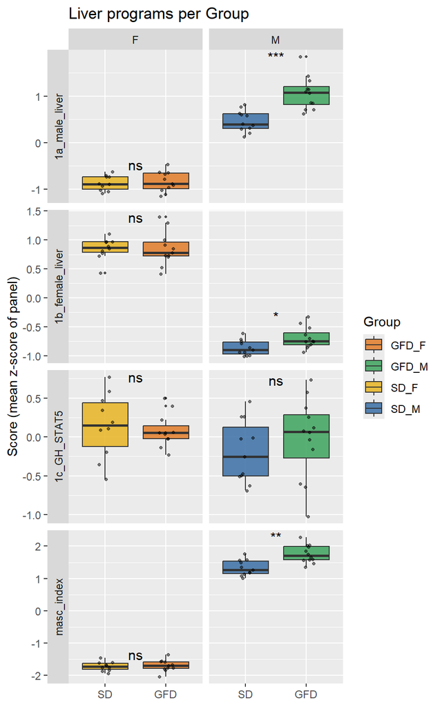

```r
sc_long <- as.data.frame(scores) %>%
  dplyr::mutate(Group = cd$Group, Diet = cd$Diet, Sex = cd$Sex) %>%
  tidyr::pivot_longer(dplyr::all_of(colnames(scores)),
                      names_to = "panel", values_to = "score") %>%
  dplyr::mutate(panel = factor(panel, levels = colnames(scores)))

pvals <- sc_long %>%
  group_by(panel, Sex) %>%
  summarise(p = wilcox.test(score ~ Diet)$p.value,
            top = max(score, na.rm = TRUE),
            rng = diff(range(score, na.rm = TRUE)),
            .groups = "drop") %>%
  mutate(y = top - 0 * rng,
         label = ifelse(p < 0.001, "***",
                 ifelse(p < 0.01,  "**",
                 ifelse(p < 0.05,  "*", "ns"))))

p <- ggplot(sc_long, aes(Diet, score)) +
  geom_boxplot(aes(fill = Group), outlier.size = 0.8, alpha = 0.85) +
  geom_point(position = position_jitter(width = 0.12), size = 0.9, alpha = 0.5) +
  facet_grid(panel ~ Sex, scales = "free_y", switch = "y") +
  scale_fill_manual(values = group_colours) +
  geom_text(data = pvals, aes(x = 1.5, y = y, label = label),
            inherit.aes = FALSE, size = 4) +
  labs(x = NULL, y = "Score (mean z-score of panel)",
       title = "Liver programs per Group")
p
```

**Open code**

```r
save(sc_long,pvals,file="../Results/figures/F5C_data_exploratory.RData")
```

## 3.13 A5: Panels for the Order and Starvation Effects

**Panels 2-4**

The same scoring approach is applied to panels that respond to collection time and feeding state: immediate-early/stress genes (2), glucocorticoid targets (3a), fasting (3b), lipogenesis (3c) and the circadian clock (4). Each score is modelled as score ~ Diet × Sex + Date, and the interaction p-values are BH-corrected across these five panels.

**Open code**

```r
a5_panels <- c("2_IEG_stress", "3a_GC_targets", "3b_fasting",
               "3c_lipogenesis", "4_circadian")

scores5 <- sapply(a5_panels, function(nm) {
 colMeans(z[panels[[nm]], , drop = FALSE], na.rm = TRUE)
})

colnames(scores5) <- a5_panels

# lm score ~ Diet * Sex + Date  for each panel
test_program <- function(sc, name, cd) {
  fit <- lm(sc ~ Diet * Sex + Date, data = cbind(cd, sc = sc))
  co  <- summary(fit)$coefficients # coefficient
  int <- grep(":", rownames(co), value = TRUE)[1]     # DietGFD:SexM
  data.frame(
    panel        = name,
    Sex_M_est    = co["SexM", "Estimate"],            # validation
    Sex_M_p      = co["SexM", "Pr(>|t|)"],
    Diet_in_F_est= co["DietGFD", "Estimate"],         # female diet effect
    Diet_in_F_p  = co["DietGFD", "Pr(>|t|)"],
    Interaction_est = co[int, "Estimate"],            # interaction
    Interaction_p   = co[int, "Pr(>|t|)"]
  )
}

# bind all results
a5_tab <- do.call(rbind,
                  lapply(colnames(scores5),
                         function(nm) test_program(scores5[, nm], nm, cd)))

a5_tab$Interaction_padj <- p.adjust(a5_tab$Interaction_p, "BH")
print(a5_tab, digits = 3, row.names = FALSE)
```

```
          panel Sex_M_est Sex_M_p Diet_in_F_est Diet_in_F_p Interaction_est
   2_IEG_stress    0.1714  0.5080       -0.0450       0.860         -0.6775
  3a_GC_targets   -0.3331  0.1977        0.1230       0.627         -0.1867
     3b_fasting   -0.3768  0.0583        0.1450       0.452          0.0408
 3c_lipogenesis   -0.1853  0.4311       -0.0598       0.796         -1.0625
    4_circadian    0.0686  0.7713        0.3534       0.135         -0.5417
 Interaction_p Interaction_padj
       0.06055          0.15138
       0.59391          0.74239
       0.87805          0.87805
       0.00186          0.00928
       0.09863          0.16439
```

**Open code**

```r
# helpers for inline numbers in the interpretation text
val <- function(tab, panel, col, d = 2) signif(tab[tab$panel == panel, col], d)
pw  <- function(tab, panel, contrast, d = 2)
  signif(tab[tab$panel == panel & tab$contrast == contrast, "p.adj"], d)

# group means
grp_means <- aggregate(scores5, list(Group = cd$Group), mean)
grp_means %>%
  kable(
    caption = "Group means for each panel",
    booktabs = TRUE,
    align = "llcccccc"
  ) %>%
  kable_styling(
    latex_options = c("hold_position"),
    bootstrap_options = c("striped", "hover", "condensed")
  )
```

Group means for each panel

| Group | 2_IEG_stress | 3a_GC_targets | 3b_fasting | 3c_lipogenesis | 4_circadian |
| --- | --- | --- | --- | --- | --- |
| GFD_F | 0.0988521 | 0.2807649 | 0.2536250 | 0.3313112 | 0.2498713 |
| GFD_M | -0.4547717 | -0.2333578 | -0.0797228 | -0.8659519 | -0.1652726 |
| SD_F | 0.1639949 | 0.1553438 | 0.1075053 | 0.3697481 | -0.1280572 |
| SD_M | 0.2481762 | -0.1674145 | -0.2643868 | 0.2772290 | 0.0468417 |

**Open code**

```r
write.xlsx(scores5 %>% as.data.frame() %>% rownames_to_column("SampleID"),
           "../Results/order_starvation_scores.xlsx",
           rownames=FALSE)
```

All pairwise group comparisons for the A5 panels, with Tukey correction within a panel (`p.value`) and BH correction across all A5 contrasts (`p.adj`).

**Open code**

```r
# run for every A5 panel
a5_pairwise <- do.call(rbind,
                       lapply(colnames(scores5),
                              function(nm) test_pairwise(scores5[, nm], nm, cd)))

a5_pairwise$p.adj <- p.adjust(a5_pairwise$p.value, method = "BH")

a5_pairwise %>%
  kable(
    caption = "Pairwise comparisons",
    booktabs = TRUE,
    align = "llcccccc"
  ) %>%
  kable_styling(
    latex_options = c("hold_position"),
    bootstrap_options = c("striped", "hover", "condensed")
  )
```

Pairwise comparisons

| panel | contrast | estimate | SE | df | t.ratio | p.value | p.adj |
| --- | --- | --- | --- | --- | --- | --- | --- |
| 2_IEG_stress | SD F - GFD F | 0.0450150 | 0.2532690 | 39 | 0.1777359 | 0.9979709 | 0.9979709 |
| 2_IEG_stress | SD F - SD M | -0.1714016 | 0.2565560 | 39 | -0.6680867 | 0.9084563 | 0.9979709 |
| 2_IEG_stress | SD F - GFD M | 0.5511149 | 0.2501482 | 39 | 2.2031540 | 0.1402694 | 0.5876066 |
| 2_IEG_stress | GFD F - SD M | -0.2164166 | 0.2490948 | 39 | -0.8688122 | 0.8208271 | 0.9979709 |
| 2_IEG_stress | GFD F - GFD M | 0.5060999 | 0.2428676 | 39 | 2.0838514 | 0.1762820 | 0.5876066 |
| 2_IEG_stress | SD M - GFD M | 0.7225166 | 0.2419675 | 39 | 2.9860070 | 0.0240963 | 0.1807222 |
| 3a_GC_targets | SD F - GFD F | -0.1230413 | 0.2508815 | 39 | -0.4904358 | 0.9607688 | 0.9979709 |
| 3a_GC_targets | SD F - SD M | 0.3330710 | 0.2541375 | 39 | 1.3105938 | 0.5618942 | 0.9979709 |
| 3a_GC_targets | SD F - GFD M | 0.3967006 | 0.2477901 | 39 | 1.6009540 | 0.3899434 | 0.8998694 |
| 3a_GC_targets | GFD F - SD M | 0.4561123 | 0.2467467 | 39 | 1.8485041 | 0.2667864 | 0.6788199 |
| 3a_GC_targets | GFD F - GFD M | 0.5197418 | 0.2405782 | 39 | 2.1603866 | 0.1524526 | 0.5876066 |
| 3a_GC_targets | SD M - GFD M | 0.0636295 | 0.2396865 | 39 | 0.2654698 | 0.9933434 | 0.9979709 |
| 3b_fasting | SD F - GFD F | -0.1449977 | 0.1906542 | 39 | -0.7605270 | 0.8715939 | 0.9979709 |
| 3b_fasting | SD F - SD M | 0.3767544 | 0.1931286 | 39 | 1.9507958 | 0.2241890 | 0.6725671 |
| 3b_fasting | SD F - GFD M | 0.1909995 | 0.1883049 | 39 | 1.0143096 | 0.7420919 | 0.9979709 |
| 3b_fasting | GFD F - SD M | 0.5217521 | 0.1875120 | 39 | 2.7824994 | 0.0396099 | 0.2376591 |
| 3b_fasting | GFD F - GFD M | 0.3359972 | 0.1828243 | 39 | 1.8378146 | 0.2715279 | 0.6788199 |
| 3b_fasting | SD M - GFD M | -0.1857549 | 0.1821467 | 39 | -1.0198091 | 0.7389281 | 0.9979709 |
| 3c_lipogenesis | SD F - GFD F | 0.0598431 | 0.2298882 | 39 | 0.2603140 | 0.9937170 | 0.9979709 |
| 3c_lipogenesis | SD F - SD M | 0.1852796 | 0.2328718 | 39 | 0.7956292 | 0.8559831 | 0.9979709 |
| 3c_lipogenesis | SD F - GFD M | 1.3076488 | 0.2270555 | 39 | 5.7591582 | 0.0000065 | 0.0001339 |
| 3c_lipogenesis | GFD F - SD M | 0.1254365 | 0.2260995 | 39 | 0.5547846 | 0.9446887 | 0.9979709 |
| 3c_lipogenesis | GFD F - GFD M | 1.2478057 | 0.2204471 | 39 | 5.6603413 | 0.0000089 | 0.0001339 |
| 3c_lipogenesis | SD M - GFD M | 1.1223692 | 0.2196301 | 39 | 5.1102713 | 0.0000508 | 0.0005081 |
| 4_circadian | SD F - GFD F | -0.3533929 | 0.2313042 | 39 | -1.5278273 | 0.4311138 | 0.9238154 |
| 4_circadian | SD F - SD M | -0.0685780 | 0.2343062 | 39 | -0.2926852 | 0.9911332 | 0.9979709 |
| 4_circadian | SD F - GFD M | 0.1196823 | 0.2284541 | 39 | 0.5238788 | 0.9528160 | 0.9979709 |
| 4_circadian | GFD F - SD M | 0.2848150 | 0.2274921 | 39 | 1.2519773 | 0.5982829 | 0.9979709 |
| 4_circadian | GFD F - GFD M | 0.4730752 | 0.2218049 | 39 | 2.1328435 | 0.1607241 | 0.5876066 |
| 4_circadian | SD M - GFD M | 0.1882602 | 0.2209829 | 39 | 0.8519222 | 0.8292380 | 0.9979709 |

### 3.13.1 Visualization

**Open code**

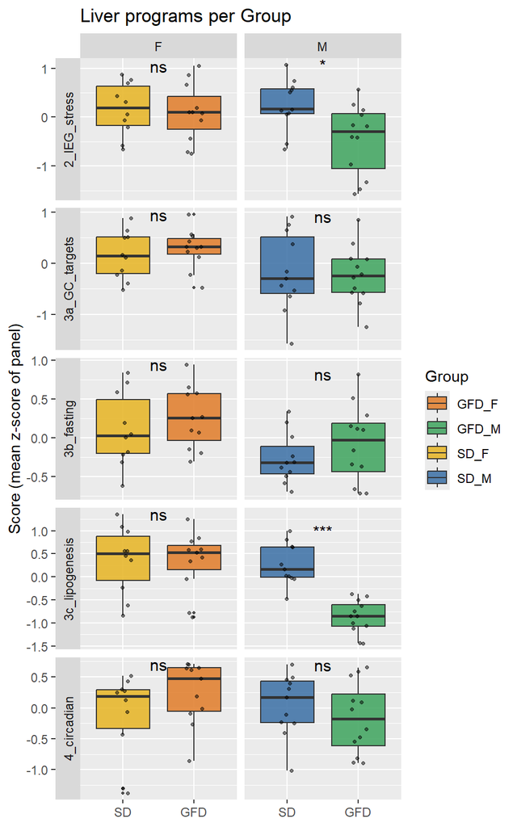

```r
# Boxplot

sc_long <- as.data.frame(scores5) %>%
  dplyr::mutate(Group = cd$Group, Diet = cd$Diet, Sex = cd$Sex) %>%
  tidyr::pivot_longer(dplyr::all_of(colnames(scores5)),
                      names_to = "panel", values_to = "score") %>%
  dplyr::mutate(panel = factor(panel, levels = colnames(scores5)))

pvals <- sc_long %>%
  group_by(panel, Sex) %>%
  summarise(p = wilcox.test(score ~ Diet)$p.value,
            top = max(score, na.rm = TRUE),
            rng = diff(range(score, na.rm = TRUE)),
            .groups = "drop") %>%
  mutate(y = top - 0 * rng,
         label = ifelse(p < 0.001, "***",
                 ifelse(p < 0.01,  "**",
                 ifelse(p < 0.05,  "*", "ns"))))

p <- ggplot(sc_long, aes(Diet, score)) +
  geom_boxplot(aes(fill = Group), outlier.size = 0.8, alpha = 0.85) +
  geom_point(position = position_jitter(width = 0.12), size = 0.9, alpha = 0.5) +
  facet_grid(panel ~ Sex, scales = "free_y", switch = "y") +
  scale_fill_manual(values = group_colours) +
  geom_text(data = pvals, aes(x = 1.5, y = y, label = label),
            inherit.aes = FALSE, size = 4) +
  labs(x = NULL, y = "Score (mean z-score of panel)",
       title = "Liver programs per Group")
p
```

**Open code**

```r
save(sc_long,pvals,file="../Results/figures/F5D_data_exploratory.RData")
```

**NoteInterpretation**

**3c_lipogenesis** (interaction est = -1.1, padj = 0.0093)

This is the only panel with a significant Diet×Sex interaction after BH correction. Diet affects the lipogenesis/cholesterol-synthesis program differently in males and females.

In females the diet effect is flat (est = -0.06, p = 0.8). The negative interaction therefore means that GFD **lowers** lipogenesis in males, while females do not change (pairwise SD M vs GFD M: padj = 5.1^{-4}).

**4_circadian** (interaction est = -0.54, p = 0.099, padj = 0.16)

No significant interaction. The other timing- and feeding-sensitive panels (IEG/stress, GC targets, fasting) also show no significant interaction after correction.

## 3.14 A6: Liver damage markers

**Panels 5-8**

The same scoring approach is applied to the liver-damage panels: fibrosis (5), ductular reaction (6), inflammation (7) and cholestasis/bile-acid handling (8). Each score is modelled as score ~ Diet × Sex + Date, with BH correction of the interaction p-values across the four panels.

**Open code**

```r
a6_panels <- c("5_fibrosis", "6_ductular", "7_inflammation", "8_cholestasis")

scores6 <- sapply(a6_panels, function(nm) {
 colMeans(z[panels[[nm]], , drop = FALSE], na.rm = TRUE)
})

colnames(scores6) <- a6_panels

# lm score ~ Diet * Sex + Date  for each panel
test_program <- function(sc, name, cd) {
  fit <- lm(sc ~ Diet * Sex + Date, data = cbind(cd, sc = sc))
  co  <- summary(fit)$coefficients # coefficient
  int <- grep(":", rownames(co), value = TRUE)[1]     # DietGFD:SexM
  data.frame(
    panel        = name,
    Sex_M_est    = co["SexM", "Estimate"],            # validation
    Sex_M_p      = co["SexM", "Pr(>|t|)"],
    Diet_in_F_est= co["DietGFD", "Estimate"],         # female diet effect
    Diet_in_F_p  = co["DietGFD", "Pr(>|t|)"],
    Interaction_est = co[int, "Estimate"],            # interaction
    Interaction_p   = co[int, "Pr(>|t|)"]
  )
}

# bind all results
a6_tab <- do.call(rbind,
                  lapply(colnames(scores6),
                         function(nm) test_program(scores6[, nm], nm, cd)))

a6_tab$Interaction_padj <- p.adjust(a6_tab$Interaction_p, "BH")
print(a6_tab, digits = 3, row.names = FALSE)
```

```
          panel Sex_M_est  Sex_M_p Diet_in_F_est Diet_in_F_p Interaction_est
     5_fibrosis   -0.7510 9.88e-05       -0.2456      0.1588         -0.5109
     6_ductular   -0.4100 1.38e-01        0.4698      0.0868         -0.6591
 7_inflammation   -0.3105 7.26e-02       -0.0362      0.8285          0.0366
  8_cholestasis   -0.0883 4.47e-01        0.1652      0.1531         -0.1323
 Interaction_p Interaction_padj
        0.0371            0.148
        0.0828            0.166
        0.8742            0.874
        0.4043            0.539
```

**Open code**

```r
# group means
grp_means <- aggregate(scores6, list(Group = cd$Group), mean)
grp_means %>%
  kable(
    caption = "Group means for each panel",
    booktabs = TRUE,
    align = "llcccccc"
  ) %>%
  kable_styling(
    latex_options = c("hold_position"),
    bootstrap_options = c("striped", "hover", "condensed")  )
```

Group means for each panel

| Group | 5_fibrosis | 6_ductular | 7_inflammation | 8_cholestasis |
| --- | --- | --- | --- | --- |
| GFD_F | 0.3716103 | 0.5822998 | 0.1566679 | 0.1757501 |
| GFD_M | -0.8089228 | -0.4187776 | -0.1580647 | -0.0725495 |
| SD_F | 0.5827976 | 0.0836159 | 0.2102022 | 0.0222631 |
| SD_M | -0.0189651 | -0.2014660 | -0.1753266 | -0.1168444 |

**Open code**

```r
write.xlsx(scores6 %>% as.data.frame() %>% rownames_to_column("SampleID"),
           "../Results/liver_damage_scores.xlsx",
           rownames=FALSE)
```

**Open code**

```r
# run for every A6 panel
a6_pairwise <- do.call(rbind,
                       lapply(colnames(scores6),
                              function(nm) test_pairwise(scores6[, nm], nm, cd)))

a6_pairwise$p.adj <- p.adjust(a6_pairwise$p.value, method = "BH")

a6_pairwise %>%
  kable(
    caption = "Pairwise comparisons",
    booktabs = TRUE,
    align = "llcccccc"
  ) %>%
  kable_styling(
    latex_options = c("hold_position"),
    bootstrap_options = c("striped", "hover", "condensed")
  )
```

Pairwise comparisons

| panel | contrast | estimate | SE | df | t.ratio | p.value | p.adj |
| --- | --- | --- | --- | --- | --- | --- | --- |
| 5_fibrosis | SD F - GFD F | 0.2456189 | 0.1709507 | 39 | 1.4367824 | 0.4847066 | 0.6462755 |
| 5_fibrosis | SD F - SD M | 0.7509665 | 0.1731693 | 39 | 4.3366026 | 0.0005528 | 0.0033169 |
| 5_fibrosis | SD F - GFD M | 1.5074490 | 0.1688442 | 39 | 8.9280477 | 0.0000000 | 0.0000000 |
| 5_fibrosis | GFD F - SD M | 0.5053476 | 0.1681332 | 39 | 3.0056381 | 0.0229393 | 0.0786489 |
| 5_fibrosis | GFD F - GFD M | 1.2618301 | 0.1639300 | 39 | 7.6973730 | 0.0000000 | 0.0000002 |
| 5_fibrosis | SD M - GFD M | 0.7564825 | 0.1633224 | 39 | 4.6318353 | 0.0002250 | 0.0017997 |
| 6_ductular | SD F - GFD F | -0.4698470 | 0.2674540 | 39 | -1.7567398 | 0.3092460 | 0.5571910 |
| 6_ductular | SD F - SD M | 0.4100414 | 0.2709251 | 39 | 1.5134863 | 0.4393983 | 0.6462755 |
| 6_ductular | SD F - GFD M | 0.5993172 | 0.2641584 | 39 | 2.2687797 | 0.1230832 | 0.3282220 |
| 6_ductular | GFD F - SD M | 0.8798884 | 0.2630461 | 39 | 3.3449976 | 0.0094921 | 0.0379685 |
| 6_ductular | GFD F - GFD M | 1.0691642 | 0.2564700 | 39 | 4.1687685 | 0.0009138 | 0.0043860 |
| 6_ductular | SD M - GFD M | 0.1892758 | 0.2555195 | 39 | 0.7407489 | 0.8800091 | 1.0000000 |
| 7_inflammation | SD F - GFD F | 0.0362124 | 0.1660838 | 39 | 0.2180366 | 0.9962779 | 1.0000000 |
| 7_inflammation | SD F - SD M | 0.3104669 | 0.1682393 | 39 | 1.8453882 | 0.2681629 | 0.5363258 |
| 7_inflammation | SD F - GFD M | 0.3100457 | 0.1640373 | 39 | 1.8900924 | 0.2488598 | 0.5363258 |
| 7_inflammation | GFD F - SD M | 0.2742545 | 0.1633466 | 39 | 1.6789728 | 0.3482444 | 0.5571910 |
| 7_inflammation | GFD F - GFD M | 0.2738334 | 0.1592630 | 39 | 1.7193783 | 0.3276477 | 0.5571910 |
| 7_inflammation | SD M - GFD M | -0.0004211 | 0.1586728 | 39 | -0.0026541 | 1.0000000 | 1.0000000 |
| 8_cholestasis | SD F - GFD F | -0.1652162 | 0.1134026 | 39 | -1.4568995 | 0.4726745 | 0.6462755 |
| 8_cholestasis | SD F - SD M | 0.0882807 | 0.1148744 | 39 | 0.7684976 | 0.8681241 | 1.0000000 |
| 8_cholestasis | SD F - GFD M | 0.0553892 | 0.1120052 | 39 | 0.4945236 | 0.9598432 | 1.0000000 |
| 8_cholestasis | GFD F - SD M | 0.2534969 | 0.1115336 | 39 | 2.2728294 | 0.1220807 | 0.3282220 |
| 8_cholestasis | GFD F - GFD M | 0.2206054 | 0.1087453 | 39 | 2.0286428 | 0.1951425 | 0.4683420 |
| 8_cholestasis | SD M - GFD M | -0.0328914 | 0.1083423 | 39 | -0.3035882 | 0.9901306 | 1.0000000 |

### 3.14.1 Visualization

Boxplots of each A6 score by diet within each sex, with unadjusted Wilcoxon stars as a visual guide.

**Open code**

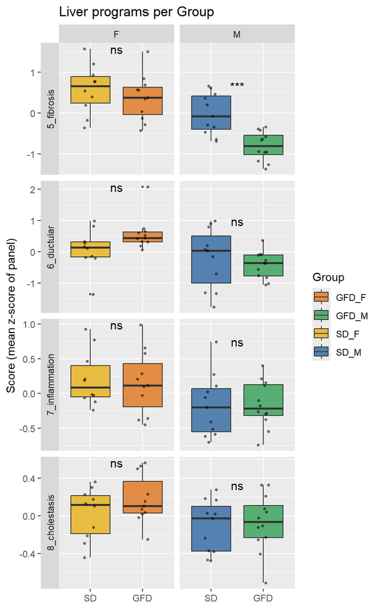

```r
# Boxplot

sc_long <- as.data.frame(scores6) %>%
  dplyr::mutate(Group = cd$Group, Diet = cd$Diet, Sex = cd$Sex) %>%
  tidyr::pivot_longer(dplyr::all_of(colnames(scores6)),
                      names_to = "panel", values_to = "score") %>%
  dplyr::mutate(panel = factor(panel, levels = colnames(scores6)))

pvals <- sc_long %>%
  group_by(panel, Sex) %>%
  summarise(p = wilcox.test(score ~ Diet)$p.value,
            top = max(score, na.rm = TRUE),
            rng = diff(range(score, na.rm = TRUE)),
            .groups = "drop") %>%
  mutate(y = top - 0 * rng,
         label = ifelse(p < 0.001, "***",
                 ifelse(p < 0.01,  "**",
                 ifelse(p < 0.05,  "*", "ns"))))

p <- ggplot(sc_long, aes(Diet, score)) +
  geom_boxplot(aes(fill = Group), outlier.size = 0.8, alpha = 0.85) +
  geom_point(position = position_jitter(width = 0.12), size = 0.9, alpha = 0.5) +
  facet_grid(panel ~ Sex, scales = "free_y", switch = "y") +
  scale_fill_manual(values = group_colours) +
  geom_text(data = pvals, aes(x = 1.5, y = y, label = label),
            inherit.aes = FALSE, size = 4) +
  labs(x = NULL, y = "Score (mean z-score of panel)",
       title = "Liver programs per Group")
p
```

**NoteInterpretation**

No panel survives BH correction on the interaction (Interaction_padj: fibrosis 0.15, ductular 0.17, cholestasis 0.54, inflammation 0.87). There is no robust sex-dependent diet effect on the liver-damage panels.

In the ductular panel, the group means suggest a non-significant opposite trend: the score goes down in males on GFD and up in females on GFD. The cholestasis panel does not show this pattern.

Two pairwise results stand out:

- **Fibrosis markers are lower in males on GFD** than in males on SD (padj = 0.0018).
- **Fibrosis markers are lower in males than in females on SD** (padj = 0.0033), a sex difference in fibrosis-marker expression.

**Save the pairwise tests**

**Open code**

```r
pairwise_table <- rbind(a4_pairwise,
                        a5_pairwise,
                        a6_pairwise)

write.xlsx(pairwise_table,file = "../Results/pairwise_panels.xlsx")

pairwise_table %>% dplyr::filter(p.adj<0.05) %>%
  kable(
    caption = "Pairwise test of selected panels",
    booktabs = TRUE,
    align = "llcccccc"
  ) %>%
  kable_styling(
    latex_options = c("hold_position"),
    bootstrap_options = c("striped", "hover", "condensed")
  )
```

Pairwise test of selected panels

| panel | contrast | estimate | SE | df | t.ratio | p.value | p.adj |
| --- | --- | --- | --- | --- | --- | --- | --- |
| 1a_male_liver | SD F - SD M | -1.3966172 | 0.0961011 | 39 | -14.532791 | 0.0000000 | 0.0000000 |
| 1a_male_liver | SD F - GFD M | -1.9866877 | 0.0937009 | 39 | -21.202449 | 0.0000000 | 0.0000000 |
| 1a_male_liver | GFD F - SD M | -1.3559284 | 0.0933063 | 39 | -14.532014 | 0.0000000 | 0.0000000 |
| 1a_male_liver | GFD F - GFD M | -1.9459988 | 0.0909737 | 39 | -21.390788 | 0.0000000 | 0.0000000 |
| 1a_male_liver | SD M - GFD M | -0.5900705 | 0.0906365 | 39 | -6.510295 | 0.0000006 | 0.0000011 |
| 1b_female_liver | SD F - SD M | 1.6696427 | 0.0828373 | 39 | 20.155692 | 0.0000000 | 0.0000000 |
| 1b_female_liver | SD F - GFD M | 1.5060028 | 0.0807683 | 39 | 18.645961 | 0.0000000 | 0.0000000 |
| 1b_female_liver | GFD F - SD M | 1.6827102 | 0.0804282 | 39 | 20.921890 | 0.0000000 | 0.0000000 |
| 1b_female_liver | GFD F - GFD M | 1.5190703 | 0.0784175 | 39 | 19.371562 | 0.0000000 | 0.0000000 |
| masc_index | SD F - SD M | -3.0662599 | 0.0964503 | 39 | -31.791091 | 0.0000000 | 0.0000000 |
| masc_index | SD F - GFD M | -3.4926905 | 0.0940413 | 39 | -37.139956 | 0.0000000 | 0.0000000 |
| masc_index | GFD F - SD M | -3.0386386 | 0.0936453 | 39 | -32.448374 | 0.0000000 | 0.0000000 |
| masc_index | GFD F - GFD M | -3.4650692 | 0.0913042 | 39 | -37.950802 | 0.0000000 | 0.0000000 |
| masc_index | SD M - GFD M | -0.4264306 | 0.0909658 | 39 | -4.687810 | 0.0001894 | 0.0003246 |
| 3c_lipogenesis | SD F - GFD M | 1.3076488 | 0.2270555 | 39 | 5.759158 | 0.0000065 | 0.0001339 |
| 3c_lipogenesis | GFD F - GFD M | 1.2478057 | 0.2204471 | 39 | 5.660341 | 0.0000089 | 0.0001339 |
| 3c_lipogenesis | SD M - GFD M | 1.1223692 | 0.2196301 | 39 | 5.110271 | 0.0000508 | 0.0005081 |
| 5_fibrosis | SD F - SD M | 0.7509665 | 0.1731693 | 39 | 4.336603 | 0.0005528 | 0.0033169 |
| 5_fibrosis | SD F - GFD M | 1.5074490 | 0.1688442 | 39 | 8.928048 | 0.0000000 | 0.0000000 |
| 5_fibrosis | GFD F - GFD M | 1.2618301 | 0.1639300 | 39 | 7.697373 | 0.0000000 | 0.0000002 |
| 5_fibrosis | SD M - GFD M | 0.7564825 | 0.1633224 | 39 | 4.631835 | 0.0002250 | 0.0017997 |
| 6_ductular | GFD F - SD M | 0.8798884 | 0.2630461 | 39 | 3.344998 | 0.0094921 | 0.0379685 |
| 6_ductular | GFD F - GFD M | 1.0691642 | 0.2564700 | 39 | 4.168768 | 0.0009138 | 0.0043860 |

# 4 Quick summary

**Sex dominates, but diet acts through sex**

Sex explains ~35% of transcriptome variance (PERMANOVA p = 10^{-4}), and there is a significant Diet×Sex interaction (R² = 4.8%, p = 0.0189): diet reshapes the liver differently in males and females.

**The diet response is essentially male-only**

1286 diet-responsive genes in males vs 3 in females, and diet inflates sex differences about 11-fold (6129 sex genes under GFD vs 564 under SD).

**GFD lowers lipogenesis and fibrosis markers in males**

**Main caveat: collection order**

GFD males were always collected last, and the male diet genes drift with collection order more than background genes. The male-specific response is consistent across analyses, but part of it may reflect time of collection rather than diet.